# Car insurance claim

Adele Ossareh

M. Saeed Pourjafar

24 June, 2021

In this project we classified the customers of the car insurance company based on many features (variables) to build a model and thus predict whether the customer claimed for the car insurance or not. In this regard we gather the data from [here](https://www.kaggle.com/mukuljh2/car-insurance-claim) and used four machine learning models namely logistic regression, KNN, SVM and XGBoost to come up with the best results based on different metrics such as accuracy, sensitivity, specificity, AIC, etc. The variables in the dataset are as follow:

- ID: Claim ID
- KIDSDRIV: Number of kids person having
- AGE: Age of the customer
- HOMEKIDS: Number of kids in the home
- YOJ: Year of joining of the customer
- INCOME: Anual income of the customer
- PARENT1: Parent is alive or not
- HOME_VAL: Home value of the customer
- MSTATUS: Marital status
- Gender: Femal/Male
- TIF: Tax Incremental Financing
- EDUCATION: Degree holds by the customer
- OCCUPATION: Job title
- TRAVTIME: Traveling time
- CAR_USE: Purpose of the car (private/commercial)
- BLUEBOOK: Legal citation system in the United States
- CAR_TYPE: Type of car (SUV/Pickup)
- RED_CAR: Color of the car (red or not red)
- OLDCLAIM: Old claim of the car
- CLM_FREQ: Number of times claim taken
- REVOKED: Claim revoked
- MVR_PTS: Claim points
- CLM_AMT: Claim amount
- CAR_AGE: Age of the car
- CLAIM_FLAG: Target variable (YES/NO)

[figure not shown]

```r
library(VIM) # Visualizing the missing values
library(mice) # Imputing the missing values
library(lattice) # For densityplot
library(dplyr)
library(readr)
library(ggplot2)
library(ggcorrplot)
library(cowplot) # For plot_grid
library(corrplot)
library(stringr)
library(caret)
library(ROCR)
library(broom) # To augment data
library(verification) # roc.area and roc.plot
library(arm) # bayesglm and binnedplot
library(bestNormalize) # yeojohnson transformation
```

## Data preparation

```r
options(scipen=999) # For removing scientific notation
# Setting the project directory
setwd("C:\\uw\\DSBA 2\\Machine Learning 1\\Project")
car <- read_csv("car.csv") # Reading the file
```

```r
glimpse(car)
```

```
## Rows: 10,302
## Columns: 25
## $ ID         <dbl> 63581743, 132761049, 921317019, 727598473, 450221861, 74314~
## $ KIDSDRIV   <dbl> 0, 0, 0, 0, 0, 0, 0, 0, 1, 0, 1, 0, 0, 0, 0, 0, 0, 0, 0, 0,~
## $ AGE        <dbl> 60, 43, 48, 35, 51, 50, 34, 54, 40, 44, 37, 34, 50, 53, 43,~
## $ HOMEKIDS   <dbl> 0, 0, 0, 1, 0, 0, 1, 0, 1, 2, 2, 0, 0, 0, 0, 0, 0, 2, 0, 3,~
## $ YOJ        <dbl> 11, 11, 11, 10, 14, NA, 12, NA, 11, 12, NA, 10, 7, 14, 5, 1~
## $ INCOME     <chr> "$67,349", "$91,449", "$52,881", "$16,039", NA, "$114,986",~
## $ PARENT1    <chr> "No", "No", "No", "No", "No", "No", "Yes", "No", "Yes", "Ye~
## $ HOME_VAL   <chr> "$0", "$257,252", "$0", "$124,191", "$306,251", "$243,925",~
## $ MSTATUS    <chr> "z_No", "z_No", "z_No", "Yes", "Yes", "Yes", "z_No", "Yes",~
## $ GENDER     <chr> "M", "M", "M", "z_F", "M", "z_F", "z_F", "z_F", "M", "z_F",~
## $ EDUCATION  <chr> "PhD", "z_High School", "Bachelors", "z_High School", "<Hig~
## $ OCCUPATION <chr> "Professional", "z_Blue Collar", "Manager", "Clerical", "z_~
## $ TRAVTIME   <dbl> 14, 22, 26, 5, 32, 36, 46, 33, 21, 30, 44, 34, 48, 15, 36, ~
## $ CAR_USE    <chr> "Private", "Commercial", "Private", "Private", "Private", "~
## $ BLUEBOOK   <chr> "$14,230", "$14,940", "$21,970", "$4,010", "$15,440", "$18,~
## $ TIF        <dbl> 11, 1, 1, 4, 7, 1, 1, 1, 6, 10, 1, 1, 7, 1, 7, 7, 6, 6, 1, ~
## $ CAR_TYPE   <chr> "Minivan", "Minivan", "Van", "z_SUV", "Minivan", "z_SUV", "~
## $ RED_CAR    <chr> "yes", "yes", "yes", "no", "yes", "no", "no", "no", "no", "~
## $ OLDCLAIM   <chr> "$4,461", "$0", "$0", "$38,690", "$0", "$19,217", "$0", "$0~
## $ CLM_FREQ   <dbl> 2, 0, 0, 2, 0, 2, 0, 0, 1, 0, 1, 0, 0, 0, 0, 2, 0, 0, 0, 0,~
## $ REVOKED    <chr> "No", "No", "No", "No", "No", "Yes", "No", "No", "No", "No"~
## $ MVR_PTS    <dbl> 3, 0, 2, 3, 0, 3, 0, 0, 2, 0, 10, 0, 1, 0, 0, 3, 3, 0, 3, 0~
## $ CLM_AMT    <chr> "$0", "$0", "$0", "$0", "$0", "$0", "$2,946", "$0", "$6,477~
## $ CAR_AGE    <dbl> 18, 1, 10, 10, 6, 17, 7, 1, 1, 10, 7, 1, 17, 11, 1, 9, 10, ~
## $ CLAIM_FLAG <dbl> 0, 0, 0, 0, 0, 0, 1, 0, 1, 0, 1, 1, 0, 1, 0, 0, 1, 0, 1, 0,~
```

```r
dim(car)
```

```
## [1] 10302    25
```

```r
car$ID <- NULL # Removing ID

# Removing the dollar sign and comma, then convert it to numeric
car$INCOME[!is.na(car$INCOME)] <- as.numeric(gsub('[$,]','',
                                          car$INCOME[!is.na(car$INCOME)]))
car$INCOME <- as.numeric(car$INCOME)
car$HOME_VAL[!is.na(car$HOME_VAL)] <- as.numeric(gsub('[$,]','',
                                          car$HOME_VAL[!is.na(car$HOME_VAL)]))
car$HOME_VAL <- as.numeric(car$HOME_VAL)
car$CLM_AMT <- as.numeric(gsub('[$,]','',car$CLM_AMT))
car$BLUEBOOK <- as.numeric(gsub('[$,]','',car$BLUEBOOK))
car$OLDCLAIM <- as.numeric(gsub('[$,]','',car$OLDCLAIM))
```

Time for dealing with missing values in **OCCUPATION** (categorical). We can either:

1. Replace the NAs with the most frequent category (it can produce unreliable results)
2. Create a new “Unknown” class for the NAs

```r
# Creating factors
car$OCCUPATION[is.na(car$OCCUPATION)] <- 'Unknown'
car$OCCUPATION <- as.factor(car$OCCUPATION)
levels(car$OCCUPATION)[levels(car$OCCUPATION)=="z_Blue Collar"] <- "Blue Collar"
table(car$OCCUPATION,ifelse(car$CLAIM_FLAG==1,"Claimed","Not claimed"))
```

```
##
##                Claimed Not claimed
##   Clerical         481        1109
##   Doctor            37         284
##   Home Maker       229         614
##   Lawyer           186         845
##   Manager          170        1087
##   Professional     325        1083
##   Student          341         558
##   Unknown          174         491
##   Blue Collar      803        1485
```

```r
car$MSTATUS <- as.factor(ifelse(gsub('z_','',car$MSTATUS) == "Yes", 1, 0))
car$PARENT1 <- as.factor(ifelse(gsub('z_','',car$PARENT1) == "Yes", 1, 0))
car$GENDER <- as.factor(ifelse(gsub('z_','',car$GENDER) == "F", 1, 0))
car$RED_CAR <- as.factor(ifelse(car$RED_CAR == "yes", 1, 0))
car$REVOKED <- as.factor(ifelse(car$REVOKED == "Yes", 1, 0))
car$CAR_USE <- as.factor(car$CAR_USE)
car$CAR_TYPE[car$CAR_TYPE == "z_SUV"] <- "SUV"
car$CAR_TYPE <- as.factor(car$CAR_TYPE)
car$CLAIM_FLAG <- as.factor(car$CLAIM_FLAG)
car$EDUCATION[car$EDUCATION == "<High School"] <- "School"
car$EDUCATION[car$EDUCATION == "z_High School"] <- "High School"
car$EDUCATION <- factor(car$EDUCATION,
                             levels = c("School",
                                        "High School",
                                        "Bachelors",
                                        "Masters",
                                        "PhD"))
```

### Outliers

#### Income

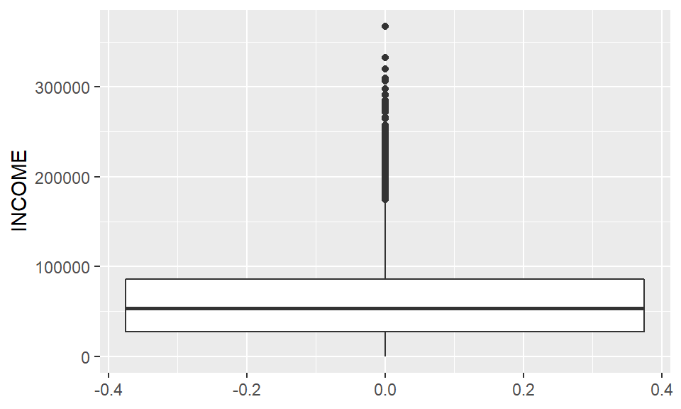

```r
# Boxplot of the income column
ggplot(car,aes(INCOME))+geom_boxplot() + coord_flip()
```

Let’s inspect those with more than $300000 income. All except one of them are male, with PHD, doctor, manager and unknown without children and at least 40 y.o. So they are perfectly sensible values.So they are extreme observation rather than outliers

```r
subset(car,car$INCOME > 300000)[,1:10]
```

```
## # A tibble: 5 x 10
##   KIDSDRIV   AGE HOMEKIDS   YOJ INCOME PARENT1 HOME_VAL MSTATUS GENDER EDUCATION
##      <dbl> <dbl>    <dbl> <dbl>  <dbl> <fct>      <dbl> <fct>   <fct>  <fct>
## 1        0    53        0     7 332339 0         738153 1       0      PhD
## 2        0    50        0    10 367030 0         885282 1       0      PhD
## 3        0    59        0    17 320127 0         750455 1       0      PhD
## 4        0    40        0    12 306277 0              0 0       1      PhD
## 5        0    48        0     8 309628 0              0 0       0      PhD
```

Table continues below

```r
subset(car,car$INCOME > 300000)[,11:22]
```

```
## # A tibble: 5 x 12
##   OCCUPATION TRAVTIME CAR_USE  BLUEBOOK   TIF CAR_TYPE RED_CAR OLDCLAIM CLM_FREQ
##   <fct>         <dbl> <fct>       <dbl> <dbl> <fct>    <fct>      <dbl>    <dbl>
## 1 Unknown          34 Commerc~    34730     6 Panel T~ 0           3019        2
## 2 Doctor           29 Private     65970     1 Minivan  1              0        0
## 3 Unknown          19 Commerc~    57970     1 Panel T~ 1           6375        2
## 4 Manager          21 Private     19520     4 Minivan  0              0        0
## 5 Manager          33 Commerc~     6300     1 Pickup   1           1953        3
## # ... with 3 more variables: REVOKED <fct>, MVR_PTS <dbl>, CLM_AMT <dbl>
```

#### Home value

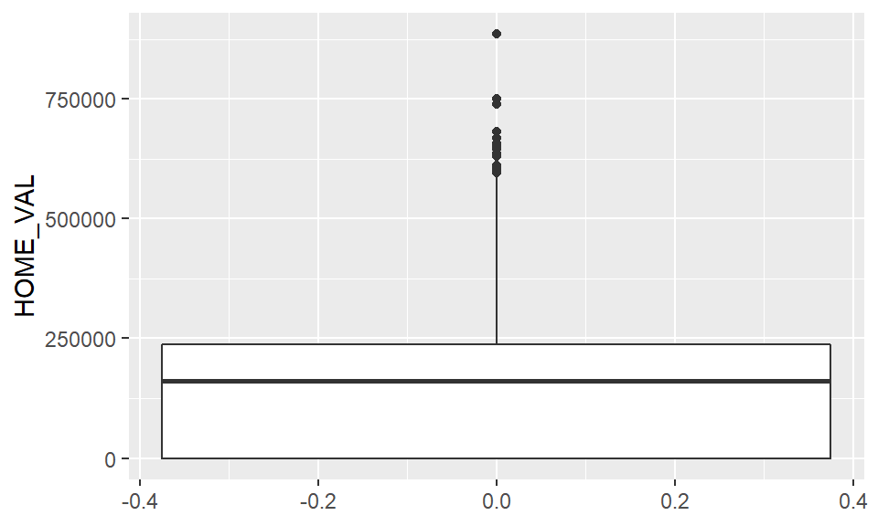

```r
# Boxplot of the Home value column
ggplot(car,aes(HOME_VAL))+geom_boxplot() + coord_flip()
```

Let’s inspect those with more than $700000 home value. Just like above, it all make sense. So no outliers here as well.

```r
subset(car,car$HOME_VAL > 700000)[,1:10]
```

```
## # A tibble: 3 x 10
##   KIDSDRIV   AGE HOMEKIDS   YOJ INCOME PARENT1 HOME_VAL MSTATUS GENDER EDUCATION
##      <dbl> <dbl>    <dbl> <dbl>  <dbl> <fct>      <dbl> <fct>   <fct>  <fct>
## 1        0    53        0     7 332339 0         738153 1       0      PhD
## 2        0    50        0    10 367030 0         885282 1       0      PhD
## 3        0    59        0    17 320127 0         750455 1       0      PhD
```

Table continues below

```r
subset(car,car$HOME_VAL > 700000)[,11:22]
```

```
## # A tibble: 3 x 12
##   OCCUPATION TRAVTIME CAR_USE  BLUEBOOK   TIF CAR_TYPE RED_CAR OLDCLAIM CLM_FREQ
##   <fct>         <dbl> <fct>       <dbl> <dbl> <fct>    <fct>      <dbl>    <dbl>
## 1 Unknown          34 Commerc~    34730     6 Panel T~ 0           3019        2
## 2 Doctor           29 Private     65970     1 Minivan  1              0        0
## 3 Unknown          19 Commerc~    57970     1 Panel T~ 1           6375        2
## # ... with 3 more variables: REVOKED <fct>, MVR_PTS <dbl>, CLM_AMT <dbl>
```

#### Bluebook

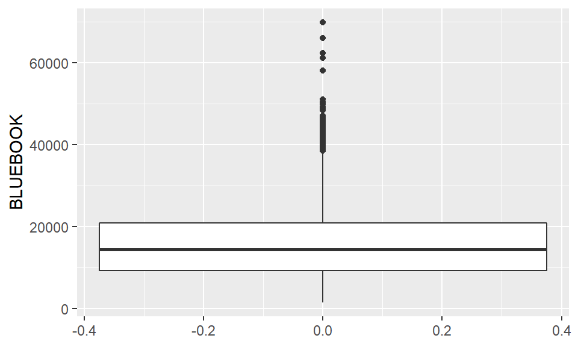

```r
# Boxplot of the Bluebook column
ggplot(car,aes(BLUEBOOK))+geom_boxplot() + coord_flip()
```

Let’s inspect those with more than $55000 price value of their car according to KBB system (Kelley Blue Book). Still no outliers.

```r
subset(car,car$BLUEBOOK > 55000)[,1:10]
```

```
## # A tibble: 5 x 10
##   KIDSDRIV   AGE HOMEKIDS   YOJ INCOME PARENT1 HOME_VAL MSTATUS GENDER EDUCATION
##      <dbl> <dbl>    <dbl> <dbl>  <dbl> <fct>      <dbl> <fct>   <fct>  <fct>
## 1        0    50        0    10 367030 0         885282 1       0      PhD
## 2        0    60        0    12 249589 0         559258 0       1      PhD
## 3        0    59        0    17 320127 0         750455 1       0      PhD
## 4        0    51        0    12 242362 0              0 0       1      PhD
## 5        0    56        0    11  70341 0         248361 1       0      PhD
```

Table continues below

```r
subset(car,car$BLUEBOOK > 55000)[,11:22]
```

```
## # A tibble: 5 x 12
##   OCCUPATION TRAVTIME CAR_USE  BLUEBOOK   TIF CAR_TYPE RED_CAR OLDCLAIM CLM_FREQ
##   <fct>         <dbl> <fct>       <dbl> <dbl> <fct>    <fct>      <dbl>    <dbl>
## 1 Doctor           29 Private     65970     1 Minivan  1              0        0
## 2 Unknown          41 Commerc~    62240     3 Panel T~ 0              0        0
## 3 Unknown          19 Commerc~    57970     1 Panel T~ 1           6375        2
## 4 Unknown          40 Commerc~    61050     4 Panel T~ 0              0        0
## 5 Unknown          26 Commerc~    69740     1 Panel T~ 1              0        0
## # ... with 3 more variables: REVOKED <fct>, MVR_PTS <dbl>, CLM_AMT <dbl>
```

#### Old claim

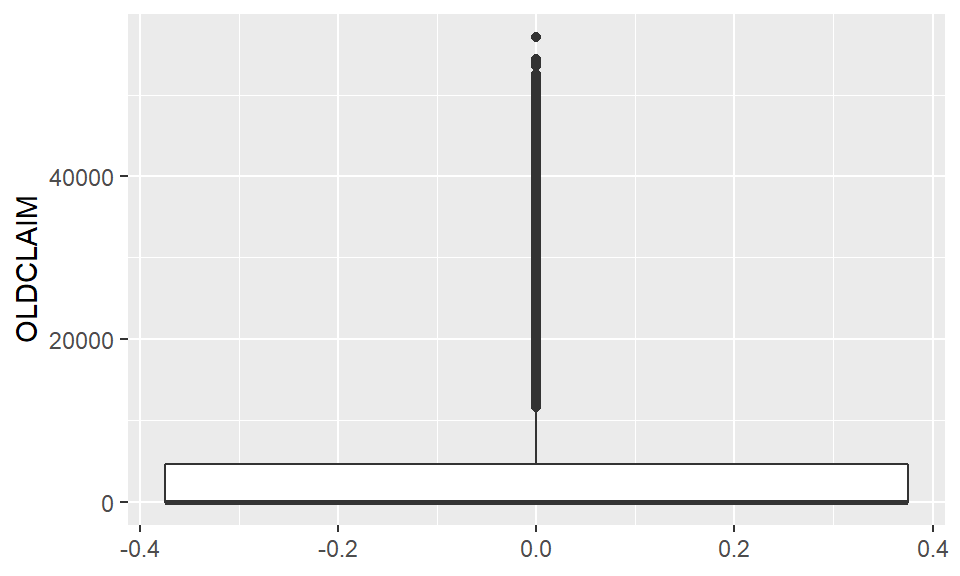

```r
# Boxplot of the Old claim column
ggplot(car,aes(OLDCLAIM))+geom_boxplot() + coord_flip()
```

The observations are so close to each other we can hardly assign any of them as a potential outlier. Similar situation in claim amount.

### Train and test split

Now it’s time to split our data into training and test sets

```r
# Dividing into train/test set
set.seed(101)
df_which_train <- createDataPartition(car$CLAIM_FLAG,
                                      p = 0.7,
                                      list = FALSE)
df_train <- car[df_which_train,]
df_test <- car[-df_which_train,]

# Sorting missing values
colSums(is.na(df_train)) %>% sort()
```

```
##   KIDSDRIV   HOMEKIDS    PARENT1    MSTATUS     GENDER  EDUCATION OCCUPATION
##          0          0          0          0          0          0          0
##   TRAVTIME    CAR_USE   BLUEBOOK        TIF   CAR_TYPE    RED_CAR   OLDCLAIM
##          0          0          0          0          0          0          0
##   CLM_FREQ    REVOKED    MVR_PTS    CLM_AMT CLAIM_FLAG        AGE        YOJ
##          0          0          0          0          0          5        384
##     INCOME   HOME_VAL    CAR_AGE
##        390        392        458
```

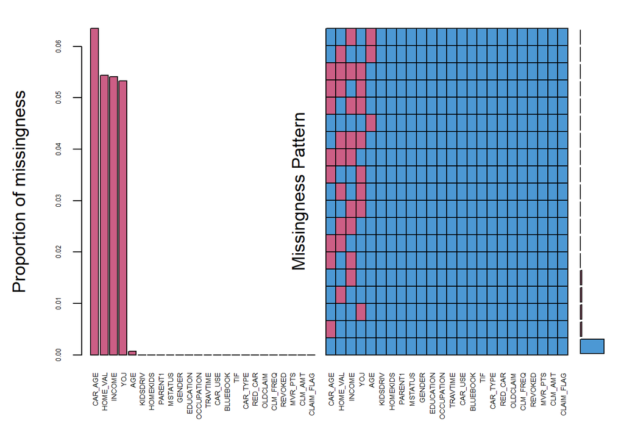

```r
# Visualizing the patterns for missing values
aggr(df_train, col=mdc(1:2),numbers=FALSE, sortVars=TRUE,
     labels=names(df_train), cex.axis=.46, gap=0.1,
     ylab=c("Proportion of missingness","Missingness Pattern"))
```

Drawing margin plot for some missing columns. The red plot indicates distribution of one feature when it is missing while the blue box is the distribution of all others when the feature is present.

#### Income vs Home value

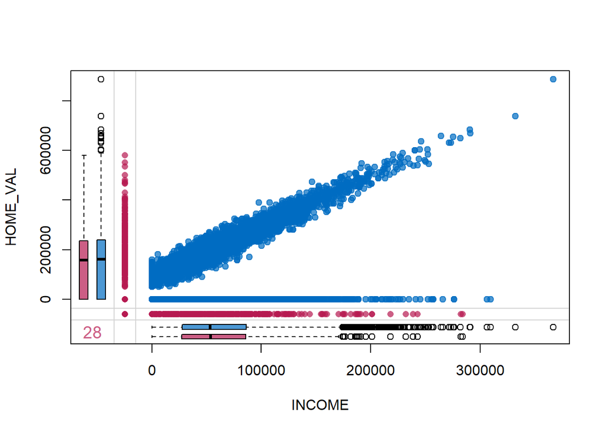

```r
marginplot(df_train[, c("INCOME","HOME_VAL")], col = mdc(1:2),
           cex.numbers = 1.2, pch = 19)
```

#### Income vs Car age

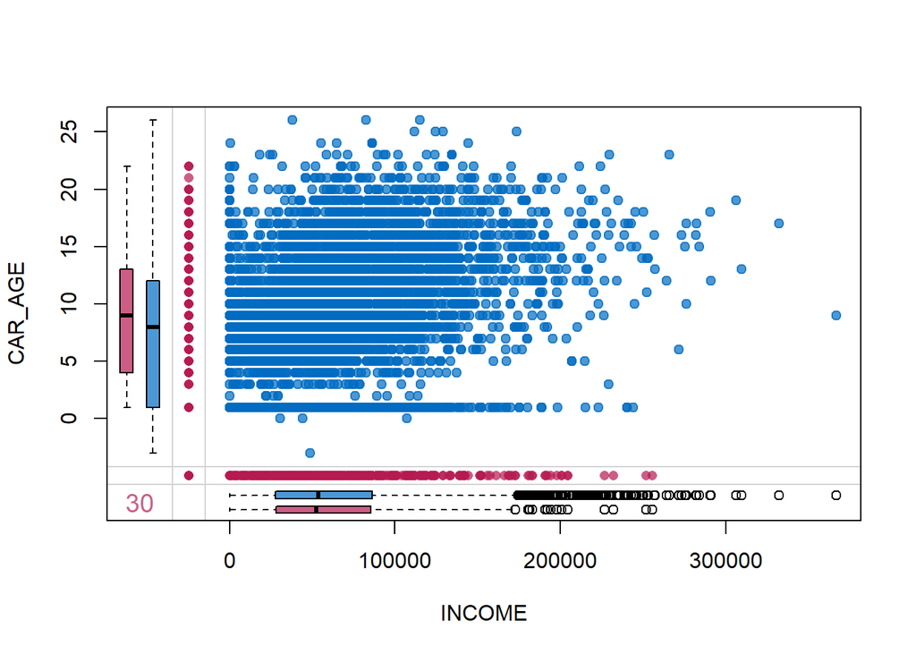

```r
marginplot(df_train[, c("INCOME","CAR_AGE")], col = mdc(1:2),
           cex.numbers = 1.2, pch = 19)
```

### Imputing NAs

Imputing missing values for AGE, YOJ, CAR_AGE, HOME_VAL and INCOME using mice based on Predictive mean matching (PMM). We can view the imputed values for missing columns for two datasets. Two red density curves are imputed ones and the blue is the observed data.

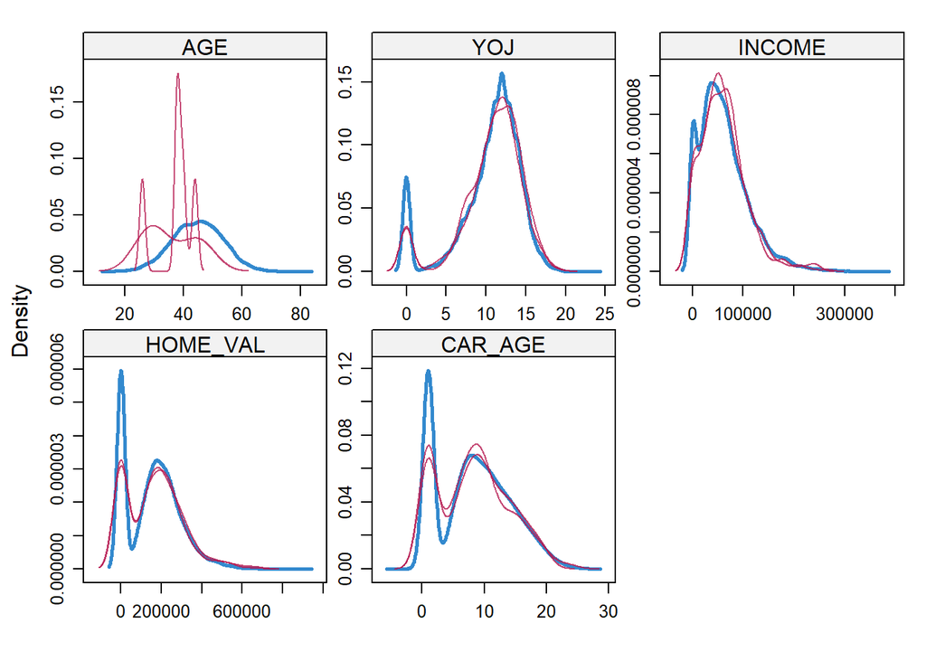

```r
imp <- mice(data = df_train[,c(2,4,5,7,23)],
            seed = 500,
            m = 2, # Number of multiple imputations
            method = "pmm",
            maxit = 10,
            print = FALSE)
densityplot(imp)
```

All except for age look promising. For age it didn’t capture the true underlying distribution. So we impute age manually with the most common observation (45)

```r
mode_ <- function(x){which.max(tabulate(x))}
df_train$AGE[is.na(df_train$AGE)] <- mode_(df_train$AGE)
# Using the same value from the training set for test set
df_test$AGE[is.na(df_test$AGE)] <- mode_(df_train$AGE)

# We can impute the other four columns with the mice results
df_train$INCOME <- complete(imp,2)$INCOME
df_train$HOME_VAL <- complete(imp,2)$HOME_VAL
df_train$CAR_AGE <- complete(imp,2)$CAR_AGE
df_train$YOJ <- complete(imp,2)$YOJ
```

```r
source("mice.reuse.R")
df_test_imp <- mice.reuse(imp, df_test[,c(2,4,5,7,23)], maxit = 1)

df_test$INCOME <- df_test_imp$`2`$INCOME
df_test$HOME_VAL <- df_test_imp$`2`$HOME_VAL
df_test$CAR_AGE <- df_test_imp$`2`$CAR_AGE
df_test$YOJ <- df_test_imp$`2`$YOJ
```

## Feature selection

Let’s plot out the categorical variables against our target (CLAIM_FLAG)

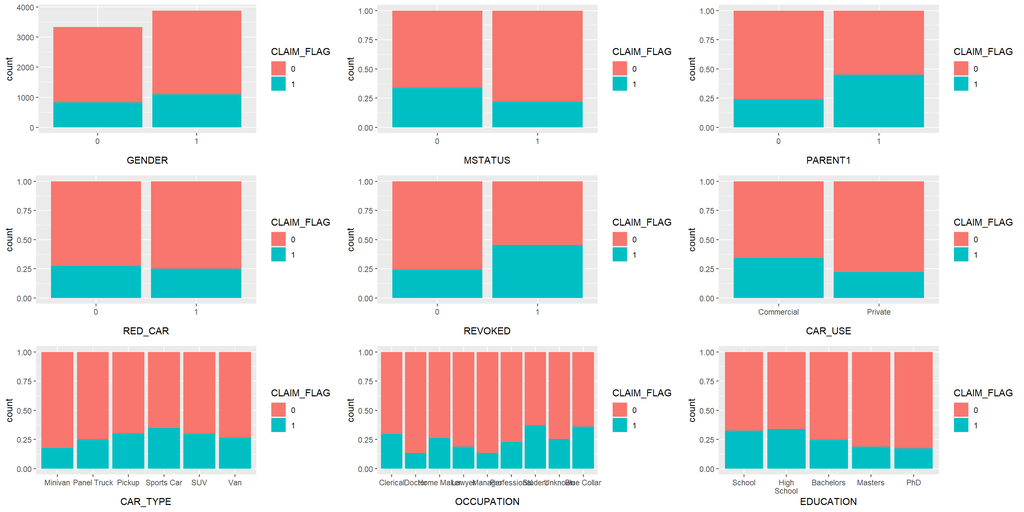

```r
options(repr.plot.width = 12, repr.plot.height = 8)
plot_grid(ggplot(df_train, aes(x=GENDER,fill=CLAIM_FLAG))+
            geom_bar()+ theme_gray(),
          ggplot(df_train, aes(x=MSTATUS,fill=CLAIM_FLAG))+
            geom_bar(position = 'fill')+theme_gray(),
          ggplot(df_train, aes(x=PARENT1,fill=CLAIM_FLAG))+
            geom_bar(position = 'fill')+theme_gray(),
          ggplot(df_train, aes(x=RED_CAR,fill=CLAIM_FLAG))+
            geom_bar(position = 'fill')+theme_gray(),
          ggplot(df_train, aes(x=REVOKED,fill=CLAIM_FLAG))+
            geom_bar(position = 'fill')+theme_gray(),
          ggplot(df_train, aes(x=CAR_USE,fill=CLAIM_FLAG))+
            geom_bar(position = 'fill')+theme_gray(),
          ggplot(df_train, aes(x=CAR_TYPE,fill=CLAIM_FLAG))+
            geom_bar(position = 'fill')+theme_gray(),
          ggplot(df_train, aes(x=OCCUPATION,fill=CLAIM_FLAG))+
            geom_bar(position = 'fill')+theme_gray(),
          ggplot(df_train, aes(x=EDUCATION,fill=CLAIM_FLAG))+
            geom_bar(position = 'fill')+theme_gray()+
            scale_x_discrete(labels = function(x) str_wrap(x, width = 10)),
          align = "h")
```

```r
# H0: GENDER and CLAIM_FLAG are independent (no association between them)
stats::fisher.test(df_train$GENDER,df_train$CLAIM_FLAG)$p # Reject the null
```

```
## [1] 0.001229507
```

```r
# H0: RED_CAR and CLAIM_FLAG are independent (no association between them)
stats::fisher.test(df_train$RED_CAR,df_train$CLAIM_FLAG)$p # Failed to reject
```

```
## [1] 0.05224425
```

From the plot and p-value, RED_CAR would be better dropped as it has no effect on predicting the target. Let’s also plot our continuous variables against the target.

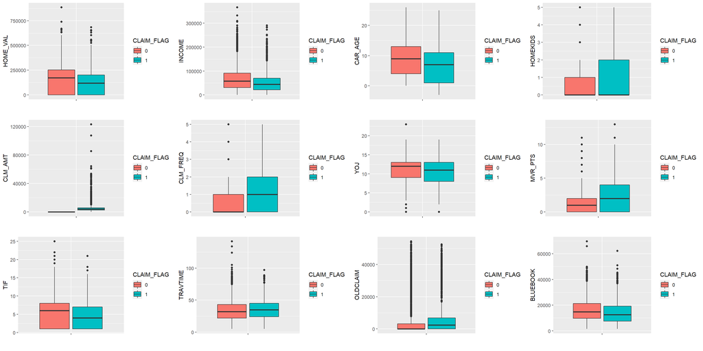

```r
options(repr.plot.width =6, repr.plot.height = 2, scipen=5)
plot_grid(ggplot(df_train, aes(y= HOME_VAL, x = "", fill = CLAIM_FLAG)) +
            geom_boxplot()+ theme_gray()+ xlab(" "),
          ggplot(df_train, aes(y= INCOME, x = "", fill = CLAIM_FLAG)) +
            geom_boxplot()+ theme_gray()+ xlab(" "),
          ggplot(df_train, aes(y= CAR_AGE, x = "", fill = CLAIM_FLAG)) +
            geom_boxplot()+ theme_gray()+ xlab(" "),
          ggplot(df_train, aes(y= HOMEKIDS, x = "", fill = CLAIM_FLAG)) +
            geom_boxplot()+ theme_gray()+ xlab(" "),
          ggplot(df_train, aes(y= CLM_AMT, x = "", fill = CLAIM_FLAG)) +
            geom_boxplot()+ theme_gray()+ xlab(" "),
          ggplot(df_train, aes(y= CLM_FREQ, x = "", fill = CLAIM_FLAG)) +
            geom_boxplot()+ theme_gray()+ xlab(" "),
          ggplot(df_train, aes(y= YOJ, x = "", fill = CLAIM_FLAG)) +
            geom_boxplot()+ theme_gray()+ xlab(" "),
          ggplot(df_train, aes(y= MVR_PTS, x = "", fill = CLAIM_FLAG)) +
            geom_boxplot()+ theme_gray()+ xlab(" "),
          ggplot(df_train, aes(y= TIF, x = "", fill = CLAIM_FLAG)) +
            geom_boxplot()+ theme_gray()+ xlab(" "),
          ggplot(df_train, aes(y= TRAVTIME, x = "", fill = CLAIM_FLAG)) +
            geom_boxplot()+ theme_gray()+ xlab(" "),
          ggplot(df_train, aes(y= OLDCLAIM, x = "", fill = CLAIM_FLAG)) +
            geom_boxplot()+ theme_gray()+ xlab(" "),
          ggplot(df_train, aes(y= BLUEBOOK, x = "", fill = CLAIM_FLAG)) +
            geom_boxplot()+ theme_gray()+ xlab(" "))
```

The median income for individuals who claimed is around 50000. Less aged car is more likely to be claimed. The median home value for individuals who claimed is below 125000

```r
# Low point-biserial correlation for YOJ, TRAVTIME and TIF
cor.test(df_train$YOJ,ifelse(as.numeric(df_train$CLAIM_FLAG) == 2,1,0))$estimate
```

```
##         cor
## -0.06658085
```

```r
cor.test(df_train$TRAVTIME,ifelse(as.numeric(df_train$CLAIM_FLAG) == 2,1,0))$estimate
```

```
##        cor
## 0.05269124
```

```r
cor.test(df_train$TIF,ifelse(as.numeric(df_train$CLAIM_FLAG) == 2,1,0))$estimate
```

```
##         cor
## -0.08300401
```

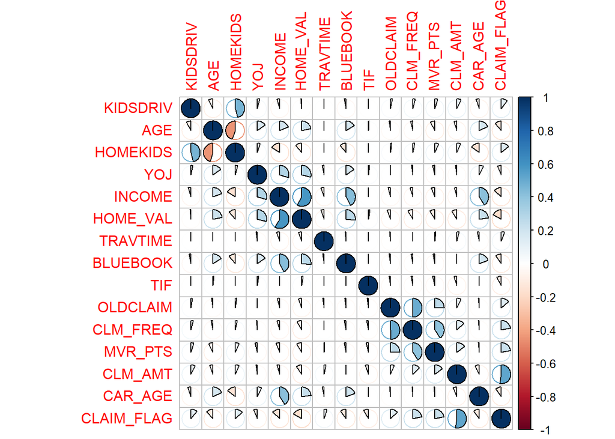

```r
# Pairwise correlation for numeric variables
df_new <- NULL
df_new$CLAIM_FLAG <- ifelse(as.numeric(df_train$CLAIM_FLAG) == 2, 1, 0)
df2 <- df_train[,-24]
df2$CLAIM_FLAG <- df_new$CLAIM_FLAG
df_numeric_vars <- sapply(df2, is.numeric) %>% which() %>% names()
df_correlations <- cor(df2[,df_numeric_vars],
      use = "pairwise.complete.obs")
corrplot::corrplot(df_correlations, method = 'pie')
```

```r
# Let's check for high correlated columns if any
findCorrelation(df_correlations,
                cutoff = 0.75,
                names = TRUE)
```

```
## character(0)
```

```r
# Better to drop TIF, YOJ and TRAVTIME due to their low predictive power
abs(df_correlations[,"CLAIM_FLAG"]) %>%
  sort(decreasing = TRUE) %>%
  names()
```

```
##  [1] "CLAIM_FLAG" "CLM_AMT"    "MVR_PTS"    "CLM_FREQ"   "HOME_VAL"
##  [6] "OLDCLAIM"   "HOMEKIDS"   "INCOME"     "AGE"        "KIDSDRIV"
## [11] "BLUEBOOK"   "CAR_AGE"    "TIF"        "YOJ"        "TRAVTIME"
```

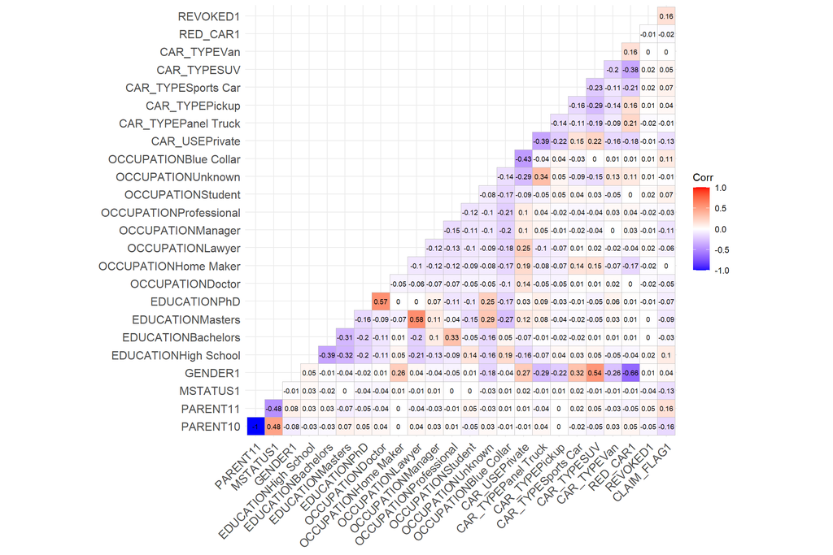

```r
# Visualizing high-correlated factor variables
is.fact <- sapply(df_train, is.factor)
factors.df <- df_train[, is.fact]
model.matrix(~0+., data=factors.df) %>%
  cor(use="pairwise.complete.obs") %>%
  ggcorrplot(show.diag = F, type="lower", lab=TRUE, lab_size=2.5)
```

```r
# No near zeor variance
nearZeroVar(df_train)
```

```
## integer(0)
```

```r
# No linear combo
findLinearCombos(df_train[, df_numeric_vars[-15]] )
```

```
## $linearCombos
## list()
##
## $remove
## NULL
```

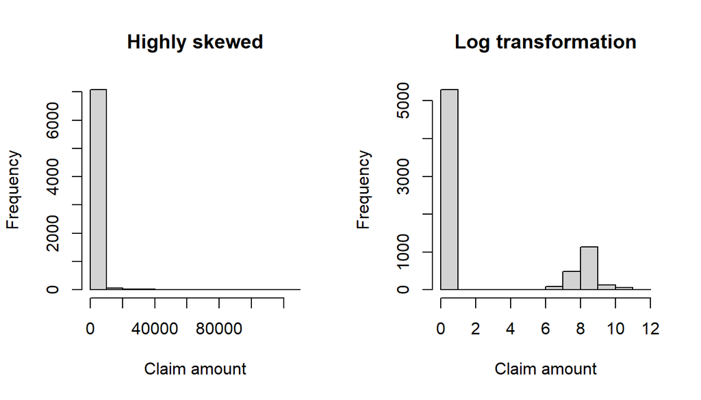

```r
par(mfrow = c(1, 2))
hist(df_train$CLM_AMT, main = "Highly skewed",xlab = "Claim amount") # Highly skewed
hist(log(df_train$CLM_AMT+1),main = "Log transformation",xlab = "Claim amount") # A bit better now
```

```r
dev.off()
df_train$CLM_AMT <- log(df_train$CLM_AMT+1)
df_test$CLM_AMT <- log(df_test$CLM_AMT+1)
cor(ifelse(as.numeric(df_train$CLAIM_FLAG) == 2, 1, 0),df_train$CLM_AMT)
```

[output not shown]

CLM_AMT (Claim amount) is highly correlated with the target. Even if we run the regression on CLM_AMT we would obtain 100% accuracy which perfectly separates 0 from 1 in target variable. Also the glm() function will raise warning:glm.fit: fitted probabilities numerically 0 or 1 occurred. This is called **Quasi-complete separation** and there are some solutions to solve it. Sometimes the problem with removing predictors is that we’re removing the predictor that best explains the response, which is usually what we aiming to do but not in this case.For at least not getting the aforementioned warning, We will use Bayesian analysis with non-informative prior assumptions as proposed by Gelman et. al (2008) using the bayesglm() in arm package. One can see, the CLM_AMT alone can result in a 100% accuracy.

```r
knitr::kable(table(ifelse(df_train$CLAIM_FLAG==1,"Yes","No"),
      ifelse(predict(bayesglm(CLAIM_FLAG~CLM_AMT, data=df_train,
                              family=binomial(link='logit'),prior.df=5),
                     type = "response") > 0.5, # condition
             "Yes", # what returned if condition TRUE
             "No")),table.attr = "style='width:30%;'")
```

|  | No | Yes |
| --- | --- | --- |
| No | 5290 | 0 |
| Yes | 0 | 1923 |

## Logistic regression

```r
set.seed(101)
car_logit1 <- glm(CLAIM_FLAG ~ ., # Providing all predictors at once
                  family =  binomial(link = "logit"),
                  data = df_train %>% dplyr::select(-c(CLM_AMT)))
summary(car_logit1) # AIC: 7148.9
```

```
##
## Call:
## glm(formula = CLAIM_FLAG ~ ., family = binomial(link = "logit"),
##     data = df_train %>% dplyr::select(-c(CLM_AMT)))
##
## Deviance Residuals:
##     Min       1Q   Median       3Q      Max
## -2.2747  -0.7514  -0.5093   0.7730   2.6474
##
## Coefficients:
##                             Estimate    Std. Error z value Pr(>|z|)
## (Intercept)            -0.6385211254  0.2707894627  -2.358 0.018374 *
## KIDSDRIV                0.3213658471  0.0625456751   5.138 2.78e-07 ***
## AGE                    -0.0033135688  0.0041291309  -0.802 0.422272
## HOMEKIDS                0.0816346339  0.0369407844   2.210 0.027114 *
## YOJ                    -0.0124234495  0.0083849994  -1.482 0.138439
## INCOME                 -0.0000022348  0.0000011128  -2.008 0.044616 *
## PARENT11                0.2461007050  0.1097688167   2.242 0.024962 *
## HOME_VAL               -0.0000010477  0.0000003451  -3.036 0.002398 **
## MSTATUS1               -0.4300078409  0.0848560315  -5.067 4.03e-07 ***
## GENDER1                 0.0250516064  0.1139553794   0.220 0.825998
## EDUCATIONHigh School    0.0106181152  0.0944077163   0.112 0.910450
## EDUCATIONBachelors     -0.2436485244  0.1144480062  -2.129 0.033262 *
## EDUCATIONMasters       -0.2765362426  0.1822495510  -1.517 0.129178
## EDUCATIONPhD           -0.1679545490  0.2170064617  -0.774 0.438954
## OCCUPATIONDoctor       -0.2495577464  0.2928787011  -0.852 0.394167
## OCCUPATIONHome Maker   -0.2471363856  0.1405559863  -1.758 0.078700 .
## OCCUPATIONLawyer        0.1204550901  0.1938799755   0.621 0.534411
## OCCUPATIONManager      -0.5196773206  0.1495680727  -3.475 0.000512 ***
## OCCUPATIONProfessional  0.0991229860  0.1264133229   0.784 0.432971
## OCCUPATIONStudent      -0.2206806855  0.1337947081  -1.649 0.099066 .
## OCCUPATIONUnknown       0.0619847847  0.2049637307   0.302 0.762333
## OCCUPATIONBlue Collar   0.1929132639  0.1065938349   1.810 0.070327 .
## TRAVTIME                0.0072316172  0.0018459452   3.918 8.94e-05 ***
## CAR_USEPrivate         -0.5707243236  0.0930329951  -6.135 8.53e-10 ***
## BLUEBOOK               -0.0000199747  0.0000053102  -3.762 0.000169 ***
## TIF                    -0.0493252883  0.0074450770  -6.625 3.47e-11 ***
## CAR_TYPEPanel Truck     0.4846423206  0.1662834918   2.915 0.003562 **
## CAR_TYPEPickup          0.3960023968  0.1021233667   3.878 0.000105 ***
## CAR_TYPESports Car      0.8262027814  0.1302321566   6.344 2.24e-10 ***
## CAR_TYPESUV             0.5641471379  0.1122688330   5.025 5.04e-07 ***
## CAR_TYPEVan             0.5021859875  0.1314952388   3.819 0.000134 ***
## RED_CAR1                0.0008815112  0.0881575267   0.010 0.992022
## OLDCLAIM               -0.0000131622  0.0000039823  -3.305 0.000949 ***
## CLM_FREQ                0.3179698914  0.0290401104  10.949  < 2e-16 ***
## REVOKED1                1.0164827256  0.0928617289  10.946  < 2e-16 ***
## MVR_PTS                 0.1307726703  0.0137908414   9.483  < 2e-16 ***
## CAR_AGE                -0.0016634451  0.0073746699  -0.226 0.821542
## ---
## Signif. codes:  0 '***' 0.001 '**' 0.01 '*' 0.05 '.' 0.1 ' ' 1
##
## (Dispersion parameter for binomial family taken to be 1)
##
##     Null deviance: 8364.9  on 7212  degrees of freedom
## Residual deviance: 7074.9  on 7176  degrees of freedom
## AIC: 7148.9
##
## Number of Fisher Scoring iterations: 5
```

```r
# AGE,YOJ,GENDER, RED_CAR and CAR_AGE are insignificant at 5%
set.seed(101)
car_logit2 <- glm(CLAIM_FLAG ~ .,
                  family =  binomial(link = "logit"),
                  data = df_train %>%
                    dplyr::select(-c(AGE,RED_CAR,CAR_AGE,CLM_AMT,YOJ,GENDER)))
summary(car_logit2) # AIC: 7142.4
```

```
##
## Call:
## glm(formula = CLAIM_FLAG ~ ., family = binomial(link = "logit"),
##     data = df_train %>% dplyr::select(-c(AGE, RED_CAR, CAR_AGE,
##         CLM_AMT, YOJ, GENDER)))
##
## Deviance Residuals:
##     Min       1Q   Median       3Q      Max
## -2.2650  -0.7511  -0.5120   0.7630   2.6426
##
## Coefficients:
##                             Estimate    Std. Error z value Pr(>|z|)
## (Intercept)            -0.9011788075  0.1920097548  -4.693 2.69e-06 ***
## KIDSDRIV                0.3126334648  0.0615900973   5.076 3.85e-07 ***
## HOMEKIDS                0.0878208582  0.0340423408   2.580 0.009887 **
## INCOME                 -0.0000023644  0.0000011060  -2.138 0.032544 *
## PARENT11                0.2560635556  0.1090132540   2.349 0.018828 *
## HOME_VAL               -0.0000010863  0.0000003439  -3.158 0.001586 **
## MSTATUS1               -0.4426264367  0.0844567865  -5.241 1.60e-07 ***
## EDUCATIONHigh School    0.0104822289  0.0940555045   0.111 0.911262
## EDUCATIONBachelors     -0.2485423955  0.1080396560  -2.300 0.021421 *
## EDUCATIONMasters       -0.2922495234  0.1665590334  -1.755 0.079323 .
## EDUCATIONPhD           -0.1816548797  0.2050838079  -0.886 0.375747
## OCCUPATIONDoctor       -0.2611519840  0.2918964697  -0.895 0.370962
## OCCUPATIONHome Maker   -0.1861953482  0.1318819213  -1.412 0.157999
## OCCUPATIONLawyer        0.1099711657  0.1934423863   0.568 0.569698
## OCCUPATIONManager      -0.5272465387  0.1490934076  -3.536 0.000406 ***
## OCCUPATIONProfessional  0.0960459700  0.1260798445   0.762 0.446187
## OCCUPATIONStudent      -0.1581053371  0.1257791574  -1.257 0.208751
## OCCUPATIONUnknown       0.0637353369  0.2047420276   0.311 0.755576
## OCCUPATIONBlue Collar   0.1902209380  0.1064554380   1.787 0.073960 .
## TRAVTIME                0.0071578996  0.0018436910   3.882 0.000103 ***
## CAR_USEPrivate         -0.5713547492  0.0929715830  -6.145 7.97e-10 ***
## BLUEBOOK               -0.0000200486  0.0000047785  -4.196 2.72e-05 ***
## TIF                    -0.0494003768  0.0074426674  -6.637 3.19e-11 ***
## CAR_TYPEPanel Truck     0.4783023813  0.1550816365   3.084 0.002041 **
## CAR_TYPEPickup          0.3942799411  0.1020734240   3.863 0.000112 ***
## CAR_TYPESports Car      0.8383330904  0.1071452507   7.824 5.11e-15 ***
## CAR_TYPESUV             0.5774767921  0.0865680207   6.671 2.54e-11 ***
## CAR_TYPEVan             0.4995391173  0.1269923379   3.934 8.37e-05 ***
## OLDCLAIM               -0.0000132735  0.0000039770  -3.338 0.000845 ***
## CLM_FREQ                0.3174231190  0.0290209394  10.938  < 2e-16 ***
## REVOKED1                1.0184366166  0.0927849987  10.976  < 2e-16 ***
## MVR_PTS                 0.1317073584  0.0137700426   9.565  < 2e-16 ***
## ---
## Signif. codes:  0 '***' 0.001 '**' 0.01 '*' 0.05 '.' 0.1 ' ' 1
##
## (Dispersion parameter for binomial family taken to be 1)
##
##     Null deviance: 8364.9  on 7212  degrees of freedom
## Residual deviance: 7078.4  on 7181  degrees of freedom
## AIC: 7142.4
##
## Number of Fisher Scoring iterations: 5
```

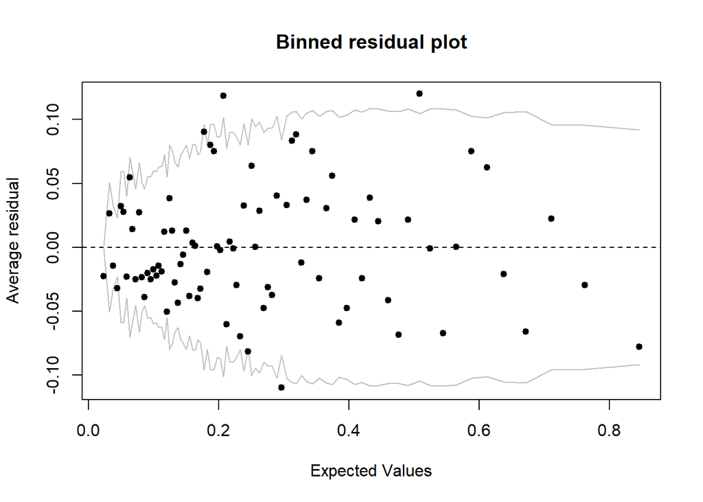

```r
# Using a binned residual plot for Logistic regression from arm package
binnedplot(fitted(car_logit2),
           residuals(car_logit2, type = "response"),
           nclass = NULL,
           xlab = "Expected Values",
           ylab = "Average residual",
           main = "Binned residual plot",
           cex.pts = 0.8,
           col.pts = 1,
           col.int = "gray")
```

```r
floor(sqrt(length(fitted(car_logit2)))) # Number of binned result (nclass)
```

```
## [1] 84
```

The gray lines indicate +/- 2 standard error bounds, within which one would expect about 95% of the binned residuals to fall, if the model were actually true. As one can see there are at least 5 outlier bins (1 - 5/84 = 0.94) some of them are negative.This means that in these bins the model is predicting a higher average rate of CLAIM_FLAG than is actually the case and vice versa for positives. Since the residuals are observed minus fitted values, so if, the rate of observed CLAIM_FLAG is less than what the model predicts, then the residuals will be negative. So the model is over-predicting CLAIM_FLAG and under-predicting for positive average residuals.We can take a look at the individual predictors against the binned residuals to see where we might refine the modelBuilding another model but this time let’s transform some variables using Yeo Johnson transformation which is a similar to Box-Cox but can also handle non-positive value (in our case 0).

```r
yeo_johnson <- function(x, lambda) {
  eps <- 0.001
  if (abs(lambda) < eps)
    log(x + 1)
  else
    ((x + 1) ^ lambda - 1) / lambda}

lambda_CLM_FREQ <- yeojohnson(df_train$CLM_FREQ)$lambda
df_train$CLM_FREQ <- yeo_johnson(df_train$CLM_FREQ,lambda_CLM_FREQ)
# And the same needs to be apply for test set
df_test$CLM_FREQ <- yeo_johnson(df_test$CLM_FREQ,lambda_CLM_FREQ)

set.seed(101)
car_logit3 <- glm(CLAIM_FLAG ~ .,
                  family =  binomial(link = "logit"),
                  data = df_train %>%
                    dplyr::select(-c(CLM_AMT,CAR_AGE,RED_CAR,GENDER,YOJ,AGE)))
summary(car_logit3) # AIC: 7094.1
```

```
##
## Call:
## glm(formula = CLAIM_FLAG ~ ., family = binomial(link = "logit"),
##     data = df_train %>% dplyr::select(-c(CLM_AMT, CAR_AGE, RED_CAR,
##         GENDER, YOJ, AGE)))
##
## Deviance Residuals:
##     Min       1Q   Median       3Q      Max
## -2.2903  -0.7491  -0.4996   0.7850   2.6654
##
## Coefficients:
##                             Estimate    Std. Error z value Pr(>|z|)
## (Intercept)            -0.9956921418  0.1933702789  -5.149 2.62e-07 ***
## KIDSDRIV                0.3135108929  0.0618084423   5.072 3.93e-07 ***
## HOMEKIDS                0.0839954949  0.0342116585   2.455 0.014082 *
## INCOME                 -0.0000023830  0.0000011075  -2.152 0.031418 *
## PARENT11                0.2637397399  0.1094606705   2.409 0.015977 *
## HOME_VAL               -0.0000010393  0.0000003449  -3.014 0.002582 **
## MSTATUS1               -0.4434250559  0.0847883845  -5.230 1.70e-07 ***
## EDUCATIONHigh School    0.0146682464  0.0945166701   0.155 0.876670
## EDUCATIONBachelors     -0.2486826030  0.1085595189  -2.291 0.021978 *
## EDUCATIONMasters       -0.2774648079  0.1670895815  -1.661 0.096799 .
## EDUCATIONPhD           -0.1743939622  0.2054911770  -0.849 0.396066
## OCCUPATIONDoctor       -0.2358350509  0.2908972546  -0.811 0.417529
## OCCUPATIONHome Maker   -0.1835453615  0.1324534227  -1.386 0.165828
## OCCUPATIONLawyer        0.0917065756  0.1940823380   0.473 0.636560
## OCCUPATIONManager      -0.5293061177  0.1494201193  -3.542 0.000397 ***
## OCCUPATIONProfessional  0.0980011435  0.1265874458   0.774 0.438826
## OCCUPATIONStudent      -0.1561435571  0.1263084570  -1.236 0.216381
## OCCUPATIONUnknown       0.0665320474  0.2050276982   0.325 0.745557
## OCCUPATIONBlue Collar   0.1952495071  0.1069611521   1.825 0.067937 .
## TRAVTIME                0.0075446855  0.0018535335   4.070 4.69e-05 ***
## CAR_USEPrivate         -0.5654942703  0.0933733499  -6.056 1.39e-09 ***
## BLUEBOOK               -0.0000199468  0.0000047919  -4.163 3.15e-05 ***
## TIF                    -0.0496106429  0.0074650073  -6.646 3.02e-11 ***
## CAR_TYPEPanel Truck     0.4571301617  0.1555699588   2.938 0.003299 **
## CAR_TYPEPickup          0.3894241461  0.1024025597   3.803 0.000143 ***
## CAR_TYPESports Car      0.8330205638  0.1073497947   7.760 8.50e-15 ***
## CAR_TYPESUV             0.5652263404  0.0868128330   6.511 7.47e-11 ***
## CAR_TYPEVan             0.4943401323  0.1275231781   3.876 0.000106 ***
## OLDCLAIM               -0.0000232183  0.0000042544  -5.457 4.83e-08 ***
## CLM_FREQ                1.8780545936  0.1456259438  12.896  < 2e-16 ***
## REVOKED1                1.1104892342  0.0941644510  11.793  < 2e-16 ***
## MVR_PTS                 0.1072053486  0.0141442618   7.579 3.47e-14 ***
## ---
## Signif. codes:  0 '***' 0.001 '**' 0.01 '*' 0.05 '.' 0.1 ' ' 1
##
## (Dispersion parameter for binomial family taken to be 1)
##
##     Null deviance: 8364.9  on 7212  degrees of freedom
## Residual deviance: 7030.1  on 7181  degrees of freedom
## AIC: 7094.1
##
## Number of Fisher Scoring iterations: 5
```

We can also change the link to “probit”. However the results will be very similar to one we had in “logit” model. Checking the binned plot based on the new model.

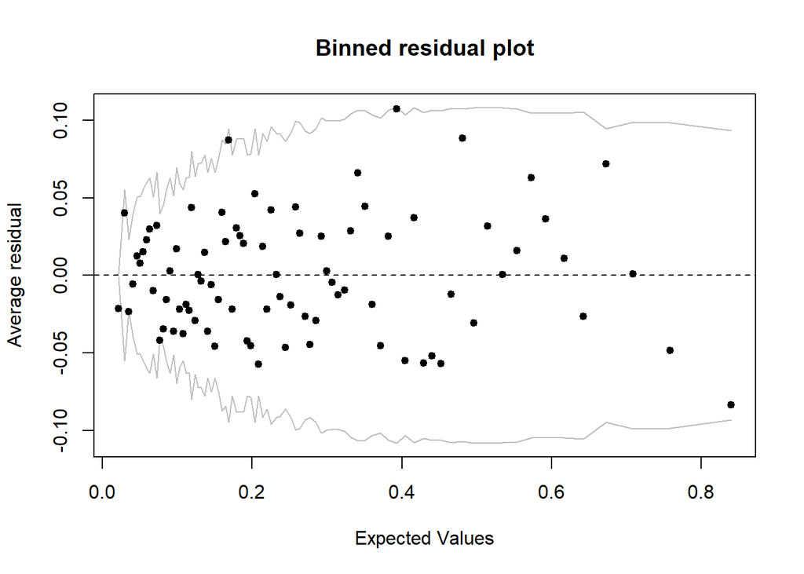

```r
binnedplot(fitted(car_logit3),
           residuals(car_logit3, type = "response"),
           nclass = NULL,
           xlab = "Expected Values",
           ylab = "Average residual",
           main = "Binned residual plot",
           cex.pts = 0.8,
           col.pts = 1,
           col.int = "gray")
```

Now there are at most 2 bins out of +/- 2 SE. 1- (2/84) = 0.9761. At least 95% of binned residuals (exactly 97%) falling in the +/- 2 SE range

```r
# Evaluation so far
fitted <- predict(car_logit3,type = "response")
knitr::kable(table(ifelse(df_train$CLAIM_FLAG == 1,"Yes","No"),
      ifelse(fitted > 0.5,"Yes","No")))
```

|  | No | Yes |
| --- | --- | --- |
| No | 4944 | 346 |
| Yes | 1306 | 617 |

```r
# representing the measures
summary_binary <- function(predicted_probs,
                           real,
                           cutoff = 0.5,
                           level_positive = "Yes",
                           level_negative = "No") {
  ctable <- confusionMatrix(as.factor(ifelse(fitted >cutoff,
                                             level_positive,
                                             level_negative)),
                            as.factor(ifelse(real == 1,"Yes","No")),
                            level_positive)
  stats <- round(c(ctable$overall[1],
                   ctable$byClass[c(1:4, 7, 11)]),
                 2)
  return(stats)
}

knitr::kable(summary_binary(as.factor(ifelse(fitted > 0.5,"Yes","No")),df_train$CLAIM_FLAG),col.names = "Value")
```

|  | Value |
| --- | --- |
| Accuracy | 0.77 |
| Sensitivity | 0.32 |
| Specificity | 0.93 |
| Pos Pred Value | 0.64 |
| Neg Pred Value | 0.79 |
| F1 | 0.43 |
| Balanced Accuracy | 0.63 |

If we want to increase the sensitivity we can change the cutoff threshold at the cost of lowering the accuracy and specificity.We can plot the curve for accuracy, sensitivity and specificity, then locate the point that these three metrics intersect with each other

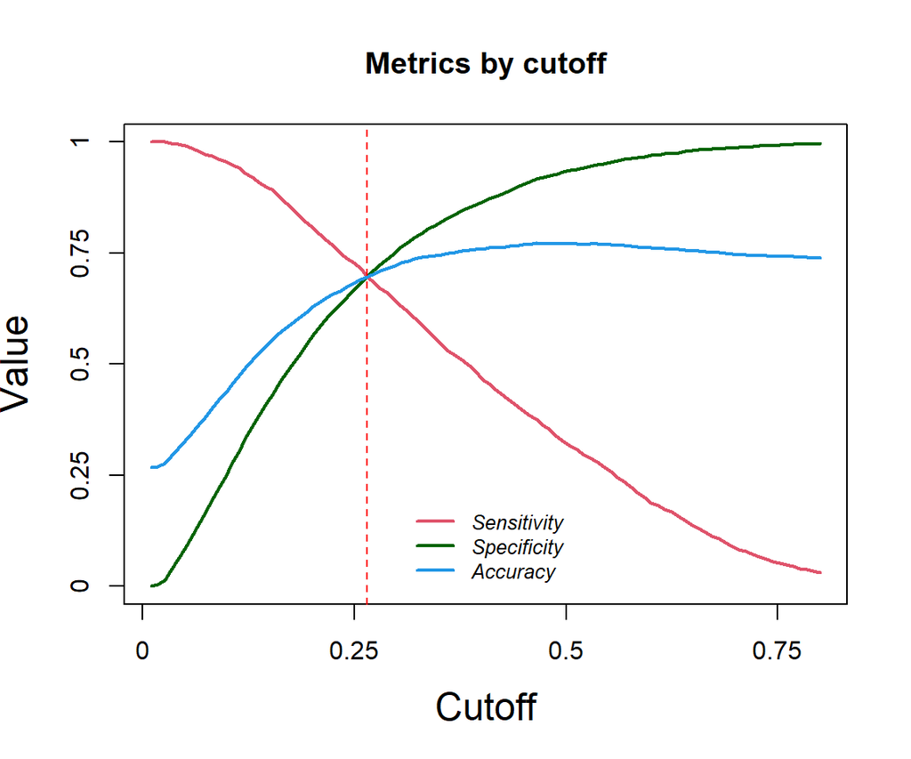

```r
# A function for evaluating metrics for different cutoff point
perform_fn <- function(cutoff) {
  predicted_claim <- factor(ifelse(fitted >= cutoff, "Yes", "No"))
  actual_claim <- factor(ifelse(df_train$CLAIM_FLAG==1,"Yes","No"))
  conf <- confusionMatrix(predicted_claim, actual_claim, positive = "Yes")
  accuray <- conf$overall[1]
  sensitivity <- conf$byClass[1]
  specificity <- conf$byClass[2]
  out <- t(as.matrix(c(sensitivity, specificity, accuray)))
  colnames(out) <- c("sensitivity", "specificity", "accuracy")
  return(out)}

# Preparing the plot and creating a matrix for storing three metric values
options(repr.plot.width =8, repr.plot.height =6)
s = seq(0.01,0.80,length=100) # Hundred cutoff points from 0.01 to 0.80
OUT = matrix(0,100,3)
for(i in 1:100){
  OUT[i,] = perform_fn(s[i])
}
# Building the plot sequentially
plot(s, OUT[,1],xlab="Cutoff",ylab="Value",cex.lab=1.5,cex.axis=1.5,
     ylim=c(0,1),type="l",lwd=2,axes=FALSE,col=2, main = "Metrics by cutoff")
axis(1,seq(0,1,length=5),seq(0,1,length=5),cex.lab=1.5)
axis(2,seq(0,1,length=5),seq(0,1,length=5),cex.lab=1.5)
lines(s,OUT[,2],col="darkgreen",lwd=2)
lines(s,OUT[,3],col=4,lwd=2)
box()
legend("bottom",col=c(2,"darkgreen",4,"darkred"),text.font =3,inset = 0.02,
       box.lty=0,cex = 0.8,
       lwd=c(2,2,2,2),c("Sensitivity","Specificity","Accuracy"))
abline(v = 0.265, col="red", lwd=1, lty=2)
```

```r
# Now let's use the new cutoff point (0.265)
knitr::kable(table(ifelse(df_train$CLAIM_FLAG == 1,"Yes","No"),
      ifelse(fitted > 0.265,"Yes","No")))
```

|  | No | Yes |
| --- | --- | --- |
| No | 3684 | 1606 |
| Yes | 582 | 1341 |

```r
knitr::kable(summary_binary(fitted,df_train$CLAIM_FLAG, cutoff = 0.265),col.names = "Value")
```

|  | Value |
| --- | --- |
| Accuracy | 0.70 |
| Sensitivity | 0.70 |
| Specificity | 0.70 |
| Pos Pred Value | 0.46 |
| Neg Pred Value | 0.86 |
| F1 | 0.55 |
| Balanced Accuracy | 0.70 |

The sensitivity increased to around 70%, accuracy also dropped to around 70%. Let’s get back to the good ol’ 0.5 as it’s the default value most of the time

```r
knitr::kable(summary_binary(predicted_probs = fitted,
               real = df_train$CLAIM_FLAG), col.names = "Value")
```

|  | Value |
| --- | --- |
| Accuracy | 0.77 |
| Sensitivity | 0.32 |
| Specificity | 0.93 |
| Pos Pred Value | 0.64 |
| Neg Pred Value | 0.79 |
| F1 | 0.43 |
| Balanced Accuracy | 0.63 |

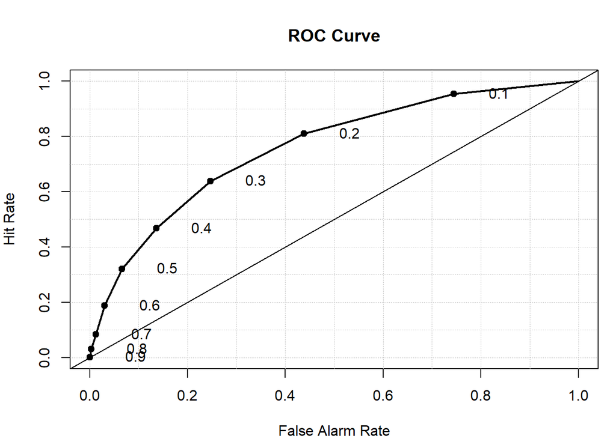

```r
# ROC curve and area
roc.plot((ifelse(as.numeric(df_train$CLAIM_FLAG) == 2,1,0)),
         fitted,threshold = seq(0.1,0.9, 0.1))
```

```r
roc.area((ifelse(as.numeric(df_train$CLAIM_FLAG) == 2,1,0)),
         fitted)$A
```

```
## [1] 0.7674899
```

```r
# Cross validation
ctrl_nocv <- trainControl(method = "none")
set.seed(101)
car_logit2_train <-
  train(CLAIM_FLAG ~ .,
        data = df_train %>%
          dplyr::select(-c(AGE,RED_CAR,CAR_AGE,CLM_AMT,YOJ,GENDER)),
        method = "glm",
        family = "binomial",
        trControl = ctrl_nocv)

car_logit2_fitted <- predict(car_logit2_train,
                             df_train,
                             type = "prob")

# Accuracy = 77% on train data
knitr::kable(summary_binary(car_logit2_fitted$`1`,df_train$CLAIM_FLAG),col.names = "Value")
```

|  | Value |
| --- | --- |
| Accuracy | 0.77 |
| Sensitivity | 0.32 |
| Specificity | 0.93 |
| Pos Pred Value | 0.64 |
| Neg Pred Value | 0.79 |
| F1 | 0.43 |
| Balanced Accuracy | 0.63 |

```r
# lets see the forecast error on the TEST sample
car_logit2_forecasts <- predict(car_logit2_train,
                                df_test,
                                type = "prob")
confusionMatrix(as.factor(ifelse(car_logit2_forecasts$`1` > 0.5 ,"Yes","No")),
                as.factor(ifelse(df_test$CLAIM_FLAG == 0,"No","Yes")),
                positive = "Yes")
```

```
## Confusion Matrix and Statistics
##
##           Reference
## Prediction   No  Yes
##        No  2129  544
##        Yes  137  279
##
##                Accuracy : 0.7795
##                  95% CI : (0.7645, 0.7941)
##     No Information Rate : 0.7336
##     P-Value [Acc > NIR] : 0.00000000216
##
##                   Kappa : 0.3306
##
##  Mcnemar's Test P-Value : < 2.2e-16
##
##             Sensitivity : 0.33900
##             Specificity : 0.93954
##          Pos Pred Value : 0.67067
##          Neg Pred Value : 0.79648
##              Prevalence : 0.26643
##          Detection Rate : 0.09032
##    Detection Prevalence : 0.13467
##       Balanced Accuracy : 0.63927
##
##        'Positive' Class : Yes
##
```

```r
# ROC/AUC on test data close to 64%
roc.area((ifelse(as.numeric(df_test$CLAIM_FLAG) == 2,1,0)),
         ifelse(car_logit2_forecasts$`1` > 0.5 ,1,0))$A
```

```
## [1] 0.6392723
```

```r
# CV
ctrl_cv10 <- trainControl(method = "cv",number = 10,
                          classProbs = TRUE,summaryFunction = twoClassSummary)

# For easier refrence
df_train$CLAIM_FLAG <- as.factor(ifelse(df_train$CLAIM_FLAG == 1,"Yes","No"))
df_test$CLAIM_FLAG <- as.factor(ifelse(df_test$CLAIM_FLAG == 1,"Yes","No"))

set.seed(101)
car_logit2_train2 <-
  train(CLAIM_FLAG ~ .,
        data = df_train %>%
          dplyr::select(-c(AGE,RED_CAR,CAR_AGE,CLM_AMT,YOJ,GENDER)),
        method = "glm",
        family = "binomial",
        metric = "ROC",
        trControl = ctrl_cv10)
car_logit2_train2
```

```
## Generalized Linear Model
##
## 7213 samples
##   17 predictor
##    2 classes: 'No', 'Yes'
##
## No pre-processing
## Resampling: Cross-Validated (10 fold)
## Summary of sample sizes: 6491, 6492, 6492, 6492, 6492, 6492, ...
## Resampling results:
##
##   ROC        Sens       Spec
##   0.7609878  0.9327032  0.3192897
```

```r
# Maybe LOOCV? NO, it takes too much time!
ctrl_loocv <- trainControl(method = "LOOCV", classProbs = TRUE,
summaryFunction = twoClassSummary)

set.seed(101)
car_logit2_train3 <-
  train(CLAIM_FLAG ~ .,
        data = df_train %>%
dplyr::select(-c(AGE,RED_CAR,CAR_AGE,CLM_AMT,YOJ,GENDER)),
        method = "glm",
        family = "binomial",
        metric = "ROC",
        trControl = ctrl_loocv)
# ROC        Sens       Spec
# 0.7550005  0.9365229  0.2947977
# car_logit2_train3
```

```r
# Now with repeated CV
ctrl_cv5x3a <- trainControl(method = "repeatedcv",number = 5,classProbs = TRUE,
                            summaryFunction = twoClassSummary,repeats = 3)
set.seed(101)
car_logit2_train3 <-
  train(CLAIM_FLAG ~ .,
        data = df_train %>%
          dplyr::select(-c(AGE,RED_CAR,CAR_AGE,CLM_AMT,YOJ,GENDER)),
        method = "glm",
        family = "binomial",
        metric = "ROC",
        trControl = ctrl_cv5x3a)
car_logit2_train3 # Not much of a difference
```

```
## Generalized Linear Model
##
## 7213 samples
##   17 predictor
##    2 classes: 'No', 'Yes'
##
## No pre-processing
## Resampling: Cross-Validated (5 fold, repeated 3 times)
## Summary of sample sizes: 5770, 5771, 5771, 5770, 5770, 5770, ...
## Resampling results:
##
##   ROC        Sens      Spec
##   0.7613413  0.931695  0.3212067
```

```r
summary(car_logit2_train3)
```

```
##
## Call:
## NULL
##
## Deviance Residuals:
##     Min       1Q   Median       3Q      Max
## -2.2903  -0.7491  -0.4996   0.7850   2.6654
##
## Coefficients:
##                              Estimate    Std. Error z value Pr(>|z|)
## (Intercept)             -0.9956921418  0.1933702789  -5.149 2.62e-07 ***
## KIDSDRIV                 0.3135108929  0.0618084423   5.072 3.93e-07 ***
## HOMEKIDS                 0.0839954949  0.0342116585   2.455 0.014082 *
## INCOME                  -0.0000023830  0.0000011075  -2.152 0.031418 *
## PARENT11                 0.2637397399  0.1094606705   2.409 0.015977 *
## HOME_VAL                -0.0000010393  0.0000003449  -3.014 0.002582 **
## MSTATUS1                -0.4434250559  0.0847883845  -5.230 1.70e-07 ***
## `EDUCATIONHigh School`   0.0146682464  0.0945166701   0.155 0.876670
## EDUCATIONBachelors      -0.2486826030  0.1085595189  -2.291 0.021978 *
## EDUCATIONMasters        -0.2774648079  0.1670895815  -1.661 0.096799 .
## EDUCATIONPhD            -0.1743939622  0.2054911770  -0.849 0.396066
## OCCUPATIONDoctor        -0.2358350509  0.2908972546  -0.811 0.417529
## `OCCUPATIONHome Maker`  -0.1835453615  0.1324534227  -1.386 0.165828
## OCCUPATIONLawyer         0.0917065756  0.1940823380   0.473 0.636560
## OCCUPATIONManager       -0.5293061177  0.1494201193  -3.542 0.000397 ***
## OCCUPATIONProfessional   0.0980011435  0.1265874458   0.774 0.438826
## OCCUPATIONStudent       -0.1561435571  0.1263084570  -1.236 0.216381
## OCCUPATIONUnknown        0.0665320474  0.2050276982   0.325 0.745557
## `OCCUPATIONBlue Collar`  0.1952495071  0.1069611521   1.825 0.067937 .
## TRAVTIME                 0.0075446855  0.0018535335   4.070 4.69e-05 ***
## CAR_USEPrivate          -0.5654942703  0.0933733499  -6.056 1.39e-09 ***
## BLUEBOOK                -0.0000199468  0.0000047919  -4.163 3.15e-05 ***
## TIF                     -0.0496106429  0.0074650073  -6.646 3.02e-11 ***
## `CAR_TYPEPanel Truck`    0.4571301617  0.1555699588   2.938 0.003299 **
## CAR_TYPEPickup           0.3894241461  0.1024025597   3.803 0.000143 ***
## `CAR_TYPESports Car`     0.8330205638  0.1073497947   7.760 8.50e-15 ***
## CAR_TYPESUV              0.5652263404  0.0868128330   6.511 7.47e-11 ***
## CAR_TYPEVan              0.4943401323  0.1275231781   3.876 0.000106 ***
## OLDCLAIM                -0.0000232183  0.0000042544  -5.457 4.83e-08 ***
## CLM_FREQ                 1.8780545936  0.1456259438  12.896  < 2e-16 ***
## REVOKED1                 1.1104892342  0.0941644510  11.793  < 2e-16 ***
## MVR_PTS                  0.1072053486  0.0141442618   7.579 3.47e-14 ***
## ---
## Signif. codes:  0 '***' 0.001 '**' 0.01 '*' 0.05 '.' 0.1 ' ' 1
##
## (Dispersion parameter for binomial family taken to be 1)
##
##     Null deviance: 8364.9  on 7212  degrees of freedom
## Residual deviance: 7030.1  on 7181  degrees of freedom
## AIC: 7094.1
##
## Number of Fisher Scoring iterations: 5
```

```r
# TRUE
identical(coef(car_logit2_train$finalModel),
          coef(car_logit2_train3$finalModel))
```

```
## [1] TRUE
```

```r
identical(coef(car_logit2_train2$finalModel),
          coef(car_logit2_train3$finalModel))
```

```
## [1] TRUE
```

### Standard residuals

Data points with an absolute standardized residuals above 3 represent possible outliers which in our case there’s none.

#### R plot

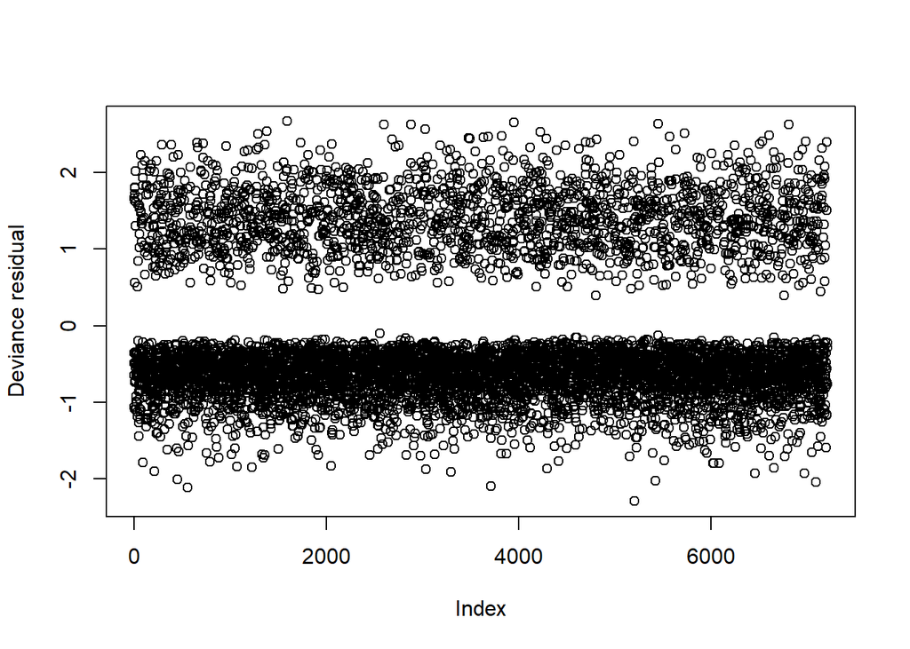

```r
model.data <- augment(car_logit3) %>%
  mutate(index = 1:n())
# Deviance residual
plot(residuals.glm(car_logit3,type = "deviance"), ylab = "Deviance residual")
```

#### ggplot

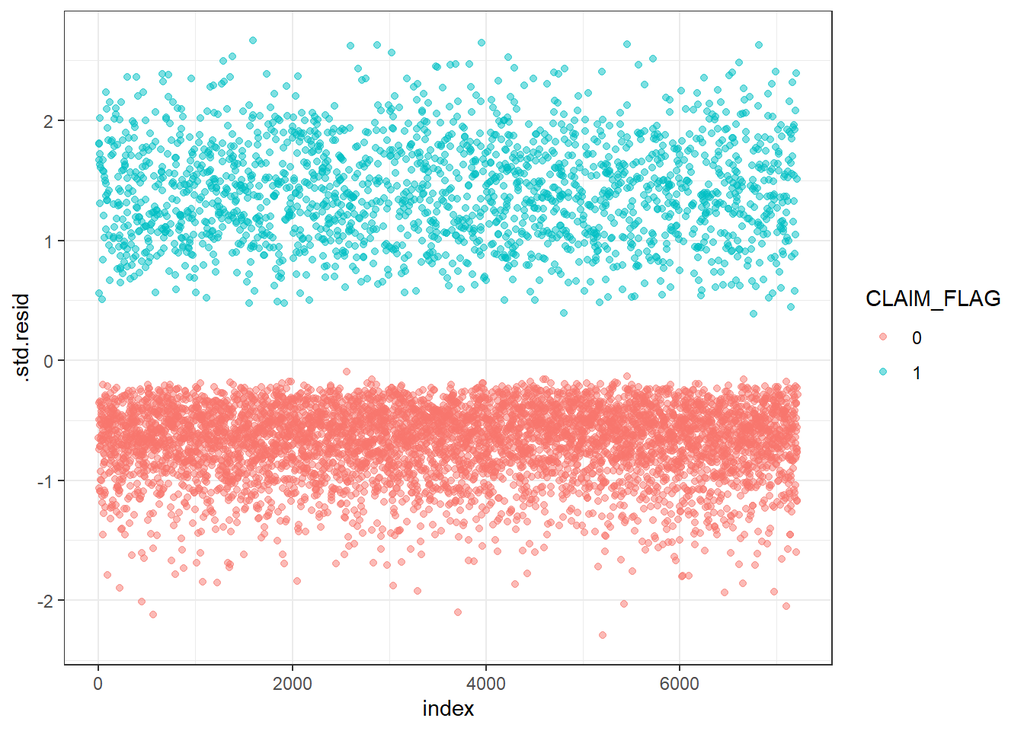

```r
# A nicer representation based on ggplot
ggplot(model.data, aes(index, .std.resid)) +
  geom_point(aes(color = CLAIM_FLAG), alpha = .5) +
  theme_bw()
```

```r
# 0 outliers
model.data %>%
  filter(abs(.std.resid) > 3)
```

```
## # A tibble: 0 x 25
## # ... with 25 variables: CLAIM_FLAG <fct>, KIDSDRIV <dbl>, HOMEKIDS <dbl>,
## #   INCOME <dbl>, PARENT1 <fct>, HOME_VAL <dbl>, MSTATUS <fct>,
## #   EDUCATION <fct>, OCCUPATION <fct>, TRAVTIME <dbl>, CAR_USE <fct>,
## #   BLUEBOOK <dbl>, TIF <dbl>, CAR_TYPE <fct>, OLDCLAIM <dbl>, CLM_FREQ <dbl>,
## #   REVOKED <fct>, MVR_PTS <dbl>, .fitted <dbl>, .resid <dbl>,
## #   .std.resid <dbl>, .hat <dbl>, .sigma <dbl>, .cooksd <dbl>, index <int>
```

## KNN

```r
# First let's use k=5 (a random number)
set.seed(101)
car_train_knn5 <-
  # From the feature selection we identified the less effective variables
  train(CLAIM_FLAG ~ .-CLM_AMT -TIF -TRAVTIME -RED_CAR -YOJ,
        data = df_train,
        method = "knn",
        tuneGrid = data.frame(k = 5))

car_train_knn5_fitted <- predict(car_train_knn5,
                                 df_train)
source("F_summary_binary_class.R")
knitr::kable(summary_binary_class(predicted_classes = car_train_knn5_fitted,
                     real = df_train$CLAIM_FLAG), col.names = "Value")
```

|  | Value |
| --- | --- |
| Accuracy | 0.78289 |
| Sensitivity | 0.37598 |
| Specificity | 0.93081 |
| Pos Pred Value | 0.66391 |
| Neg Pred Value | 0.80405 |
| F1 | 0.48008 |
| Balanced Accuracy | 0.65339 |

```r
# Nearest odd number to avoid ties would be k=85
k_value <- data.frame(k = round(sqrt(dim(df_train)[1])))

# 5 fold repeated CV and k=85
ctrl_cv5x3a <- trainControl(method = "repeatedcv",number = 5,repeats = 3)
set.seed(101)
car_train_knn85 <-
  train(CLAIM_FLAG ~ .-CLM_AMT -TIF -TRAVTIME -RED_CAR -YOJ,
        data = df_train,
        method = "knn",
        trControl = ctrl_cv5x3a,
        tuneGrid = k_value)

# Fitted values - prediction on the training sample
car_train_knn85_fitted <- predict(car_train_knn85,
                                  df_train)

# Almost everything decreased!
knitr::kable(summary_binary_class(predicted_classes = car_train_knn85_fitted,
                     real = df_train$CLAIM_FLAG), col.names = "Value")
```

|  | Value |
| --- | --- |
| Accuracy | 0.73825 |
| Sensitivity | 0.04576 |
| Specificity | 0.98998 |
| Pos Pred Value | 0.62411 |
| Neg Pred Value | 0.74053 |
| F1 | 0.08527 |
| Balanced Accuracy | 0.51787 |

```r
# Comparing the results in the test sample
# About the same result as we had in training set
car_train_knn85_forecasts <- predict(car_train_knn85,
                                     df_test)
knitr::kable(summary_binary_class(predicted_classes = car_train_knn85_forecasts,
                     real = df_test$CLAIM_FLAG), col.names = "Value")
```

|  | Value |
| --- | --- |
| Accuracy | 0.73551 |
| Sensitivity | 0.03767 |
| Specificity | 0.98897 |
| Pos Pred Value | 0.55357 |
| Neg Pred Value | 0.73887 |
| F1 | 0.07053 |
| Balanced Accuracy | 0.51332 |

```r
# Now we experiment with different values for k
different_k <- data.frame(k = seq(5, 97, 4))

# Here comes the pain
ctrl_cv3x2a <- trainControl(method = "repeatedcv",number = 3,classProbs = TRUE,
                            summaryFunction = twoClassSummary,repeats = 2)
set.seed(101)
car_train_knn_tuned <-
  train(CLAIM_FLAG ~ .-CLM_AMT -TIF -TRAVTIME -RED_CAR -YOJ,
        data = df_train,
        method = "knn",
        metric = "ROC",
        trControl = ctrl_cv3x2a,
        tuneGrid = different_k)

# CV
ctrl_cv5 <- trainControl(method = "cv",number = 5,
                         classProbs = TRUE,summaryFunction = twoClassSummary)

# Optimal k based on scaled variables from range [0,1] since
# rescaling features is one way that can be used to improve the performance
# of Distance-based algorithms such as KNN
set.seed(101)
car_train_knn_tuned_scaled <-
  train(CLAIM_FLAG ~ .-CLM_AMT -TIF -TRAVTIME -RED_CAR -YOJ,
        data = df_train,
        method = "knn",
        trControl = ctrl_cv5,
        tuneGrid = different_k,
        preProcess = c("range"),
        metric = "ROC")
```

### K for tuned

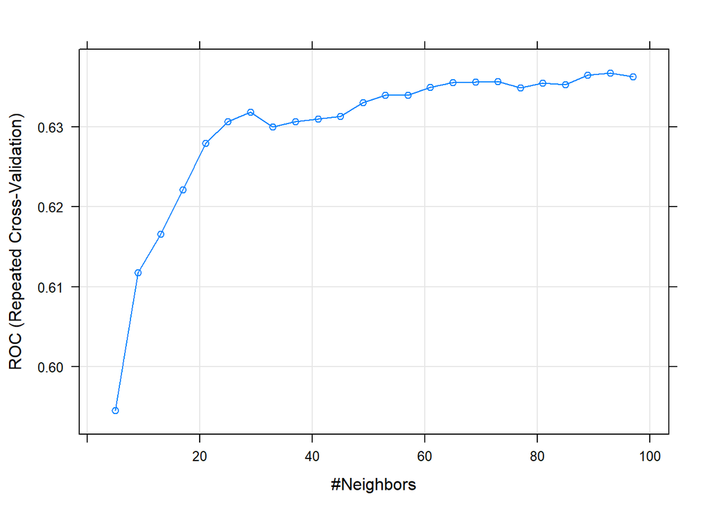

```r
# Plotting the values for k
plot(car_train_knn_tuned) # k = 93
```

### K for tuned & scaled

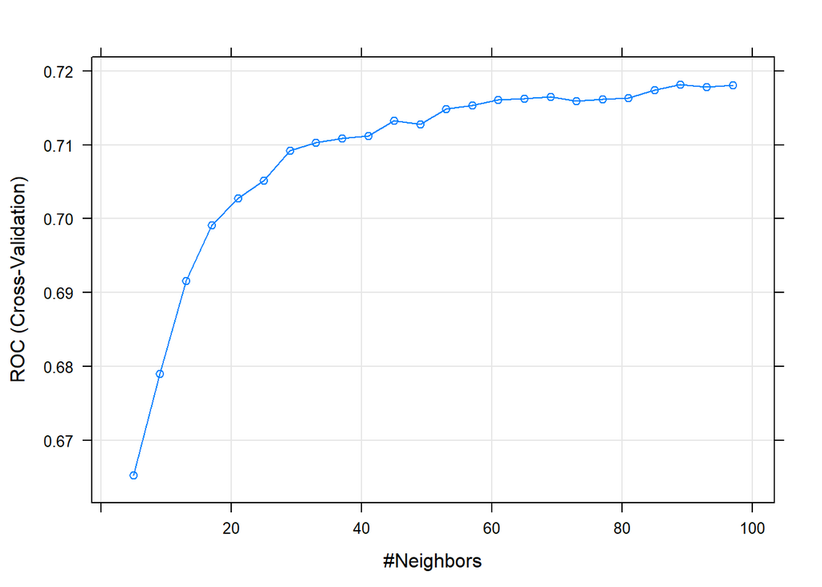

```r
# Plotting the values for k
plot(car_train_knn_tuned_scaled) # k = 89
```

### Comparing models

```r
# Storing all the prediction in a dataframe
car_test_forecasts <-
  data.frame(car_train_knn5 = predict(car_train_knn5,
                                                   df_test),
             car_train_knn85 = predict(car_train_knn85,
                                       df_test),
             car_train_knn_tuned = predict(car_train_knn_tuned,
                                           df_test),
             car_train_knn_tuned_scaled = predict(car_train_knn_tuned_scaled,
                                                  df_test))
source("F_summary_binary.R")
knitr::kable(sapply(car_test_forecasts,
       function(x) summary_binary_class(predicted_classes = x,
                                        real = df_test$CLAIM_FLAG)) %>%t())
```

|  | Accuracy | Sensitivity | Specificity | Pos Pred Value | Neg Pred Value | F1 | Balanced Accuracy |
| --- | --- | --- | --- | --- | --- | --- | --- |
| car_train_knn5 | 0.71253 | 0.25152 | 0.87996 | 0.43215 | 0.76398 | 0.31797 | 0.56574 |
| car_train_knn85 | 0.73551 | 0.03767 | 0.98897 | 0.55357 | 0.73887 | 0.07053 | 0.51332 |
| car_train_knn_tuned | 0.73519 | 0.03524 | 0.98941 | 0.54717 | 0.73847 | 0.06621 | 0.51232 |
| car_train_knn_tuned_scaled | 0.74102 | 0.06926 | 0.98500 | 0.62637 | 0.74450 | 0.12473 | 0.52713 |

One can see the last model which we trained on CV with scaled variable has the highest accuracy but suffers from low sensitivity

## SVM

Now let’s build the model based on SVM algorithm. We will use three different kernel such as linear, polynomial radial to train our model.

### Linear

```r
# CV
trctrl <- trainControl(method = "cv", number = 5)
# What if we include CLM_AMT? 100% accuracy.
set.seed(101)
svm_Linear <- train(CLAIM_FLAG ~.-TIF -TRAVTIME -RED_CAR -YOJ, data = df_train,
                    method = "svmLinear",
                    trControl=trctrl,
                    preProcess = c("center", "scale"),
                    tuneLength = 10)
knitr::kable(svm_Linear$results)
```

| C | Accuracy | Kappa | AccuracySD | KappaSD |
| --- | --- | --- | --- | --- |
| 1 | 1 | 1 | 0 | 0 |

```r
set.seed(101)
svm_Linear <- train(CLAIM_FLAG ~.-CLM_AMT -TIF -TRAVTIME -RED_CAR -YOJ,
                    data = df_train,
                    method = "svmLinear",
                    trControl=trctrl,
                    preProcess = c("center", "scale"),
                    tuneLength = 10)
knitr::kable(svm_Linear$results)
```

| C | Accuracy | Kappa | AccuracySD | KappaSD |
| --- | --- | --- | --- | --- |
| 1 | 0.7333981 | 0 | 0.0002785 | 0 |

```r
#Not run, it will take too much time. However we ran it once and the result has been reported.
grid <- expand.grid(C = c(0,0.01, 0.05, 0.1, 0.25, 0.5,
0.75, 1, 1.25, 1.5, 1.75, 2,5))
svm_Linear_Grid <- train(CLAIM_FLAG ~.-CLM_AMT -TIF -TRAVTIME -RED_CAR -YOJ,
                         data = df_train,
                         method = "svmLinear",
                         trControl=trctrl,
                         preProcess = c("center", "scale"),
                         tuneGrid = grid,
                         tuneLength = 10)
svm_Linear_Grid # Optimal C = 1.75, Accuracy = 0.7542989
test_pred_grid <- predict(svm_Linear_Grid, newdata = df_test)
confusionMatrix(table(test_pred_grid, df_test$CLAIM_FLAG))
# Prediction on test set:
# Accuracy : 0.7547
# Sensitivity : 0.9453
# Specificity : 0.2467
```

### Polynomial

```r
# Not run,it will take too much time. However we ran it once and the result has been reported.
svm_parametersPoly <- expand.grid(C = c(1.75),
                                  degree = 2:4,
                                  scale = 1)
trctrl <- trainControl(method = "cv", number = 3)
set.seed(101)
svm_Poly <- train(CLAIM_FLAG ~.-CLM_AMT -TIF -TRAVTIME -RED_CAR -YOJ,
                    data = df_train,
                    method = "svmPoly",
                    trControl=trctrl,
                    tuneGrid = svm_parametersPoly)

svm_Poly
# Accuracy 0.7493415
# The final values used for the model were degree = 2, scale = 1 and C = 1.75

test_pred_grid <- predict(svm_Poly, newdata = df_test)
confusionMatrix(table(test_pred_grid, df_test$CLAIM_FLAG))
# Accuracy : 0.7659
# Sensitivity : 0.9012
# Specificity : 0.3369
```

### RBF

```r
# First without any CV
set.seed(101)
car.svm_Radial1 <- train(CLAIM_FLAG ~.-CLM_AMT -TIF -TRAVTIME -RED_CAR -YOJ,
                         data = df_train,
                         method = "svmRadial",
                         trControl = ctrl_nocv)
car.svm_Radial1$finalModel@error # High training error : 0.234854
```

```
## [1] 0.2348537
```

```r
# Accuracy : 0.7572
confusionMatrix(predict(car.svm_Radial1,df_test),
                df_test$CLAIM_FLAG, positive = "Yes")
```

```
## Confusion Matrix and Statistics
##
##           Reference
## Prediction   No  Yes
##        No  2208  692
##        Yes   58  131
##
##                Accuracy : 0.7572
##                  95% CI : (0.7417, 0.7722)
##     No Information Rate : 0.7336
##     P-Value [Acc > NIR] : 0.001458
##
##                   Kappa : 0.177
##
##  Mcnemar's Test P-Value : < 2.2e-16
##
##             Sensitivity : 0.15917
##             Specificity : 0.97440
##          Pos Pred Value : 0.69312
##          Neg Pred Value : 0.76138
##              Prevalence : 0.26643
##          Detection Rate : 0.04241
##    Detection Prevalence : 0.06118
##       Balanced Accuracy : 0.56679
##
##        'Positive' Class : Yes
##
```

```r
# Now with CV and different values for C and Sigma
parametersC_sigma <-
  expand.grid(C = c(2,5),
              sigma = c(0.01,0.02))
trctrl <- trainControl(method = "cv", number = 3)

set.seed(101)
car.svm_Radial2 <- train(CLAIM_FLAG ~.-CLM_AMT -TIF -TRAVTIME -RED_CAR -YOJ,
                         data = df_train,
                         method = "svmRadial",
                         tuneGrid = parametersC_sigma,
                         trControl = trctrl)
car.svm_Radial2$finalModel@error
```

```
## [1] 0.1979759
```

```r
# The model has less training error compare to the previous one and also the
# accuracy improved a bit. The hyperparameters for the final optimal model are:
# C = 2 and sigma =  0.02
# Accuracy : 0.7663
confusionMatrix(predict(car.svm_Radial2,df_test),
                df_test$CLAIM_FLAG, positive = "Yes")
```

```
## Confusion Matrix and Statistics
##
##           Reference
## Prediction   No  Yes
##        No  2147  603
##        Yes  119  220
##
##                Accuracy : 0.7663
##                  95% CI : (0.7509, 0.7811)
##     No Information Rate : 0.7336
##     P-Value [Acc > NIR] : 0.00001709
##
##                   Kappa : 0.2643
##
##  Mcnemar's Test P-Value : < 2.2e-16
##
##             Sensitivity : 0.26731
##             Specificity : 0.94748
##          Pos Pred Value : 0.64897
##          Neg Pred Value : 0.78073
##              Prevalence : 0.26643
##          Detection Rate : 0.07122
##    Detection Prevalence : 0.10974
##       Balanced Accuracy : 0.60740
##
##        'Positive' Class : Yes
##
```

Based on these three kernels we can see that RBF performs the best.

## XGBoost

```r
# We need to sequentially tune the hyperparameters
params_xgboost <- expand.grid(nrounds = seq(20, 100, 10),
                              max_depth = c(6),
                              eta = c(0.5),
                              gamma = 1,
                              colsample_bytree = c(0.3),
                              min_child_weight = c(100),
                              subsample = 0.8)

ctrl_cv5x3 <- trainControl(method = "repeatedcv",
                           number = 5,
                           repeats = 3,
                           classProbs = TRUE)
set.seed(101)
car_xgboost_tuned <- train(CLAIM_FLAG ~.-CLM_AMT -TIF -TRAVTIME -RED_CAR -YOJ,
                           data = df_train,
                           method = "xgbTree",
                           trControl = ctrl_cv5x3,
                           tuneGrid  = params_xgboost)
car_xgboost_tuned
```

```
## eXtreme Gradient Boosting
##
## 7213 samples
##   23 predictor
##    2 classes: 'No', 'Yes'
##
## No pre-processing
## Resampling: Cross-Validated (5 fold, repeated 3 times)
## Summary of sample sizes: 5770, 5771, 5771, 5770, 5770, 5770, ...
## Resampling results across tuning parameters:
##
##   nrounds  Accuracy   Kappa
##    20      0.7594624  0.2619812
##    30      0.7605259  0.2761152
##    40      0.7592783  0.2749894
##    50      0.7596474  0.2797563
##    60      0.7602941  0.2844045
##    70      0.7595545  0.2827933
##    80      0.7592775  0.2830414
##    90      0.7584456  0.2823372
##   100      0.7584457  0.2828839
##
## Tuning parameter 'max_depth' was held constant at a value of 6
## Tuning
##  parameter 'min_child_weight' was held constant at a value of 100
##
## Tuning parameter 'subsample' was held constant at a value of 0.8
## Accuracy was used to select the optimal model using the largest value.
## The final values used for the model were nrounds = 30, max_depth = 6, eta
##  = 0.5, gamma = 1, colsample_bytree = 0.3, min_child_weight = 100 and
##  subsample = 0.8.
```

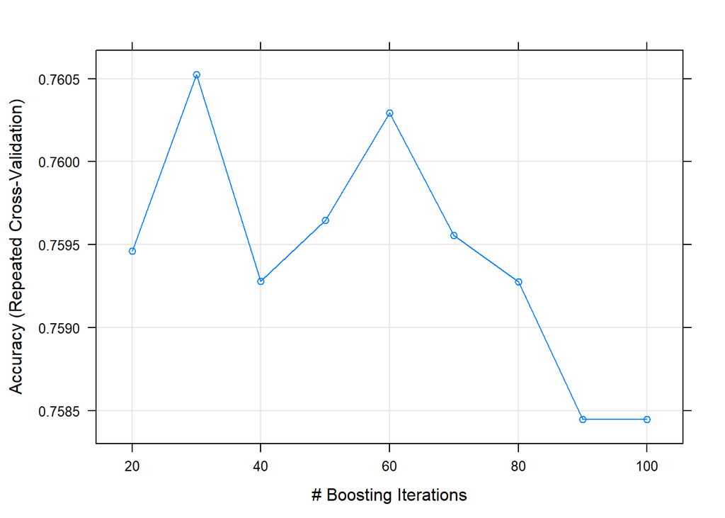

```r
plot(car_xgboost_tuned)
```

```r
# One can see the value of optimal nround is low (30) so we can
# modifying the eta (to lower learning rate) and choose higher max depth
params_xgboost1 <- expand.grid(nrounds = seq(30, 100, 10),
                               max_depth = c(8),
                               eta = c(0.17),
                               gamma = 1,
                               colsample_bytree = c(0.3),
                               min_child_weight = c(100),
                               subsample = 0.8)
set.seed(101)
car_xgboost_tuned1 <- train(CLAIM_FLAG ~.-CLM_AMT -TIF -TRAVTIME -RED_CAR -YOJ,
                            data = df_train,
                            method = "xgbTree",
                            trControl = ctrl_cv5x3,
                            tuneGrid  = params_xgboost1)
car_xgboost_tuned1 #nrounds = 90
```

```
## eXtreme Gradient Boosting
##
## 7213 samples
##   23 predictor
##    2 classes: 'No', 'Yes'
##
## No pre-processing
## Resampling: Cross-Validated (5 fold, repeated 3 times)
## Summary of sample sizes: 5770, 5771, 5771, 5770, 5770, 5770, ...
## Resampling results across tuning parameters:
##
##   nrounds  Accuracy   Kappa
##    30      0.7565050  0.2127316
##    40      0.7599243  0.2419387
##    50      0.7609873  0.2570323
##    60      0.7607096  0.2613692
##    70      0.7611251  0.2672826
##    80      0.7606171  0.2674286
##    90      0.7616797  0.2739360
##   100      0.7612178  0.2738739
##
## Tuning parameter 'max_depth' was held constant at a value of 8
## Tuning
##  parameter 'min_child_weight' was held constant at a value of 100
##
## Tuning parameter 'subsample' was held constant at a value of 0.8
## Accuracy was used to select the optimal model using the largest value.
## The final values used for the model were nrounds = 90, max_depth = 8, eta
##  = 0.17, gamma = 1, colsample_bytree = 0.3, min_child_weight = 100
##  and subsample = 0.8.
```

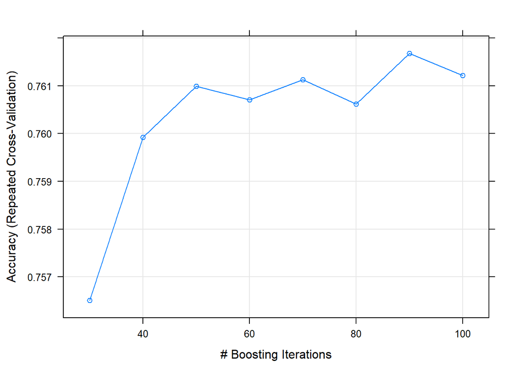

```r
plot(car_xgboost_tuned1)
```

```r
# Now let's tune tree parameters
# (max_depth, min_child_weight and colsample_bytree)
params_xgboost2 <- expand.grid(nrounds = 90,
                               max_depth = seq(90, 130, 10),
                               eta = c(0.17),
                               gamma = 1,
                               colsample_bytree = c(0.3),
                               min_child_weight = seq(50, 80, 10),
                               subsample = 0.8)
set.seed(101)
car_xgboost_tuned2 <- train(CLAIM_FLAG ~.-CLM_AMT -TIF -TRAVTIME -RED_CAR -YOJ,
                            data = df_train,
                            method = "xgbTree",
                            trControl = ctrl_cv5x3,
                            tuneGrid  = params_xgboost2)
car_xgboost_tuned2
```

```
## eXtreme Gradient Boosting
##
## 7213 samples
##   23 predictor
##    2 classes: 'No', 'Yes'
##
## No pre-processing
## Resampling: Cross-Validated (5 fold, repeated 3 times)
## Summary of sample sizes: 5770, 5771, 5771, 5770, 5770, 5770, ...
## Resampling results across tuning parameters:
##
##   max_depth  min_child_weight  Accuracy   Kappa
##    90        50                0.7641754  0.2915720
##    90        60                0.7631589  0.2885023
##    90        70                0.7651466  0.2909403
##    90        80                0.7638985  0.2853941
##   100        50                0.7650542  0.2943619
##   100        60                0.7639446  0.2887793
##   100        70                0.7639444  0.2882427
##   100        80                0.7624195  0.2804207
##   110        50                0.7639445  0.2928987
##   110        60                0.7637603  0.2892890
##   110        70                0.7656083  0.2906334
##   110        80                0.7628356  0.2804717
##   120        50                0.7637597  0.2903562
##   120        60                0.7637136  0.2879239
##   120        70                0.7644534  0.2882825
##   120        80                0.7642690  0.2856481
##   130        50                0.7652851  0.2953545
##   130        60                0.7633441  0.2869911
##   130        70                0.7635289  0.2848770
##   130        80                0.7652852  0.2897371
##
## Tuning parameter 'nrounds' was held constant at a value of 90
## Tuning
##  'colsample_bytree' was held constant at a value of 0.3
## Tuning
##  parameter 'subsample' was held constant at a value of 0.8
## Accuracy was used to select the optimal model using the largest value.
## The final values used for the model were nrounds = 90, max_depth = 110, eta
##  = 0.17, gamma = 1, colsample_bytree = 0.3, min_child_weight = 70 and
##  subsample = 0.8.
```

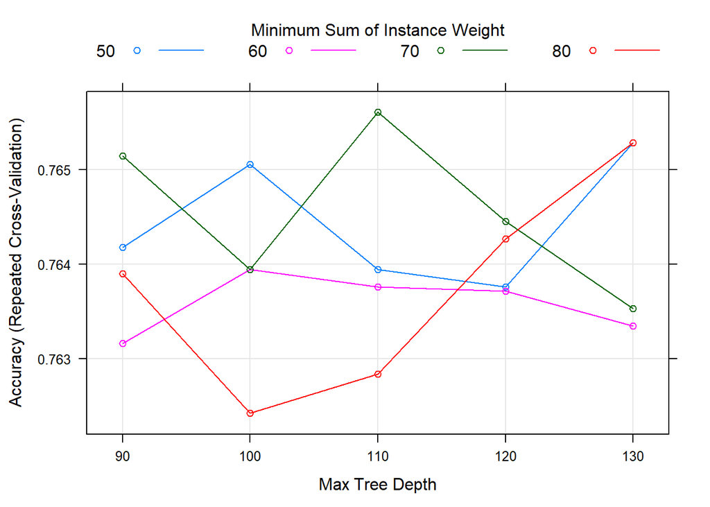

```r
plot(car_xgboost_tuned2)
```

```r
# min_child_weight = 70 and max_depth = 110
# Now tuning the colsample_bytree

params_xgboost3 <- expand.grid(nrounds = 70,
                               max_depth = 110,
                               eta = c(0.17),
                               gamma = 1,
                               colsample_bytree = seq(0.3, 0.9, 0.1),
                               min_child_weight = 70,
                               subsample = 0.8)
set.seed(101)
car_xgboost_tuned3 <- train(CLAIM_FLAG ~.-CLM_AMT -TIF -TRAVTIME -RED_CAR -YOJ,
                            data = df_train,
                            method = "xgbTree",
                            trControl = ctrl_cv5x3,
                            tuneGrid  = params_xgboost3)
car_xgboost_tuned3 # colsample_bytree = 0.8
```

```
## eXtreme Gradient Boosting
##
## 7213 samples
##   23 predictor
##    2 classes: 'No', 'Yes'
##
## No pre-processing
## Resampling: Cross-Validated (5 fold, repeated 3 times)
## Summary of sample sizes: 5770, 5771, 5771, 5770, 5770, 5770, ...
## Resampling results across tuning parameters:
##
##   colsample_bytree  Accuracy   Kappa
##   0.3               0.7625585  0.2772852
##   0.4               0.7655159  0.2901163
##   0.5               0.7631592  0.2870192
##   0.6               0.7652392  0.2939101
##   0.7               0.7654239  0.2951350
##   0.8               0.7663945  0.3011042
##   0.9               0.7647304  0.2960329
##
## Tuning parameter 'nrounds' was held constant at a value of 70
## Tuning
##  'min_child_weight' was held constant at a value of 70
## Tuning
##  parameter 'subsample' was held constant at a value of 0.8
## Accuracy was used to select the optimal model using the largest value.
## The final values used for the model were nrounds = 70, max_depth = 110, eta
##  = 0.17, gamma = 1, colsample_bytree = 0.8, min_child_weight = 70 and
##  subsample = 0.8.
```

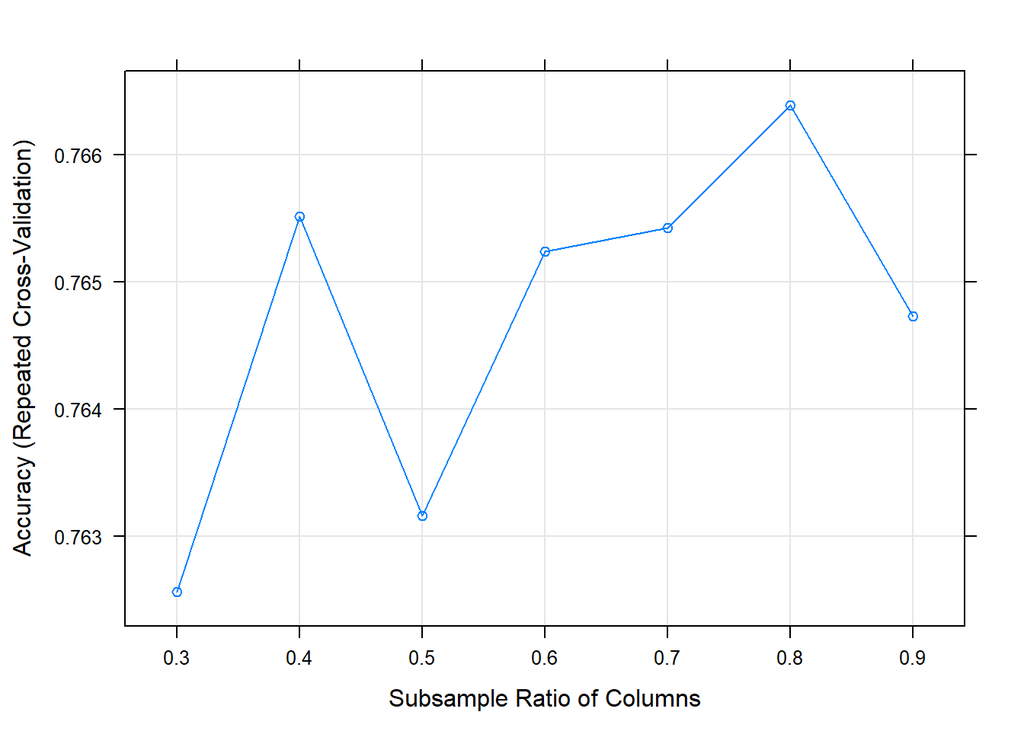

```r
plot(car_xgboost_tuned3)
```